# Mental Jenga

Liang Zhou, Kevin Smith, Josh Tenenbaum & Tobias Gerstenberg

January 31, 2022

# 1 Load packages

```r
library("Hmisc")
library("gtools")
library("magick")
library("tidyjson")
library("png")
library("RSQLite")
library("tidyverse")
library("patchwork")
library("corrr")
library("ggrepel")
library("ggpubr")
library("lsr")
library("knitr")
library("grid")
library("xtable")
```

```r
theme_set(theme_classic() +
            theme(text = element_text(size = 20,
                                      family = "Helvetica")))

opts_chunk$set(comment = "",
               results = "hold",
               fig.show = "hold")

# suppress grouping warning
options(dplyr.summarise.inform = F)
```

# 2 Helper functions

```r
# L2
l2 = function(x, y, w = NULL) {
  if (is.null(w)) {
    return(mean((x - y)^2))
  } else {
    return(weighted.mean((x-y)^2, w))
  }
}

# root mean squared error
rmse = function(x, y) {
  return(sqrt(mean(l2(x, y))))
}

# natural log clipped between 0.01 and 0.99
logclip = function(x) {
  return(log(pmax(pmin(0.99, x), 0.01)))
}

# get the clipped nll, with optional weights
nll = function(p, x, w = NULL) {
  if (is.null(w)) {
    return(-mean(p * logclip(x) + (1 - p) * logclip(1 - x)))
  } else {
    return(-weighted.mean(p * logclip(x) + (1 - p) * logclip(1 - x), w))
  }
}

# go from logit to probability, used for fitting logistic models
logit2prob = function(logit) {
  odds = exp(logit)
  prob = odds / (1 + odds)
  return(prob)
}
```

# 3 Load Data

- load all experiment data, including data from MTurk as well as stimuli and features

## 3.1 Experiment 1

```r
load("data/exp1_participants.RData")
load("data/exp1_selection.RData")
load("data/exp1_prediction.RData")
load("data/exp1_responsibility.RData")
load("data/exp1_info.RData")

load("cache/exp1_features_all.RData")
load("cache/exp1_model.RData")
```

## 3.2 Experiment 2

```r
load("data/exp2_participants.RData")
load("data/exp2_selection.RData")
load("data/exp2_prediction.RData")
load("data/exp2_responsibility.RData")
load("data/exp2_info.RData")

load("cache/exp2_features_all.RData")
load("cache/exp2_model.RData")
```

## 3.3 Experiment 3

```r
load("data/exp3_participants.RData")
load("data/exp3_prediction.RData")
load("data/exp3_responsibility.RData")
load("data/exp3_info.RData")

load("cache/exp3_features_all.RData")
load("cache/exp3_model.RData")
```

# 4 Preprocessing

- set seed

```r
set.seed(1)
```

## 4.1 Demographics

### 4.1.1 Experiment 1

```r
df.exp1.participants %>%
  mutate(age = as.numeric(age)) %>%
  summarize(age.mean = mean(age),
            age.sd = sd(age),
            nfemale = sum(sex == "female"),
            nmale = sum(sex == "male"))

# experiment_3 is selection
# experiment_2, condition 0 is prediction
# experiment_2, condition 1 is responsibility
df.exp1.participants %>%
  mutate(across(.cols = c(age, time),
                .fns = ~ as.numeric(.))) %>%
  group_by(experiment, condition) %>%
  summarize(time.mean = mean(time),
    time.sd = sd(time),
    exclude = sum(exclude),
    n = n(),
    nfemale = sum(sex == "female"),
    nmale = sum(sex == "male")) %>%
    mutate(across(.cols = contains("time"),
                .fns = ~ round(., 2)))
```

```
  age.mean   age.sd nfemale nmale
1 34.09091 12.14976      47    74
# A tibble: 3 x 8
# Groups:   experiment [2]
  experiment   condition time.mean time.sd exclude     n nfemale nmale
  <chr>        <chr>         <dbl>   <dbl>   <int> <int>   <int> <int>
1 experiment_2 0              9.86    6.49      11    42      14    28
2 experiment_2 1              8.88    8.9        6    41      17    24
3 experiment_3 0             15.7     8.31       0    38      16    22
```

### 4.1.2 Experiment 2

```r
df.exp2.participants %>%
  mutate(age = as.numeric(age)) %>%
  summarize(age.mean = mean(age),
            age.sd = sd(age),
            nfemale = sum(sex == "female"),
            nmale = sum(sex == "male"))

# experiment_5 is selection
# experiment_4, condition 0 is prediction
# experiment_4, condition 1 is responsibility
df.exp2.participants %>%
  mutate(across(.cols = c(age, time),
                .fns = ~ as.numeric(.))) %>%
  group_by(experiment, condition) %>%
  summarize(time.mean = mean(time),
    time.sd = sd(time),
    exclude = sum(exclude),
    n = n(),
    nfemale = sum(sex == "female"),
    nmale = sum(sex == "male")) %>%
    mutate(across(.cols = contains("time"),
                .fns = ~ round(., 2)))
```

```
  age.mean   age.sd nfemale nmale
1 36.36434 11.29639      59    70
# A tibble: 3 x 8
# Groups:   experiment [2]
  experiment   condition time.mean time.sd exclude     n nfemale nmale
  <chr>        <chr>         <dbl>   <dbl>   <int> <int>   <int> <int>
1 experiment_4 0             11.6     5.24       2    42      20    22
2 experiment_4 1              7.86    3.48       3    43      18    25
3 experiment_5 0             13.0     6.87       1    44      21    23
```

### 4.1.3 Experiment 3

```r
df.exp3.participants %>%
  mutate(age = as.numeric(age)) %>%
  summarize(age.mean = mean(age),
            age.sd = sd(age),
            nfemale = sum(gender == "female"),
            nmale = sum(gender == "male"))

# calculating total time spent in conditions
df.exp3.prediction %>%
  summarize(mean(rt), sd(rt)) / 60 / 1000 * 42
df.exp3.responsibility %>%
  summarize(mean(rt), sd(rt)) / 60 / 1000 * 42
```

```
# A tibble: 1 x 4
  age.mean age.sd nfemale nmale
     <dbl>  <dbl>   <int> <int>
1     37.2   12.1      32    49
  mean(rt)   sd(rt)
1 7.027109 5.041616
  mean(rt)   sd(rt)
1 6.734848 7.986447
```

## 4.2 Remove test trials

- catch trials are trial 5 in experiment 1, and trial 43 in experiment 2
- catch trial already removed in experiment 2 participant data

```r
df.exp1.info = df.exp1.info %>%
  filter(trial != 5, index != 0)
df.exp1.features.all = df.exp1.features.all %>%
  filter(trial != 5)
df.exp2.info = df.exp2.info %>%
  filter(trial != 43, index != 0)
df.exp2.features.all = df.exp2.features.all %>%
  filter(trial != 43)
df.exp3.info = df.exp3.info %>%
  filter(trial != 43)
```

## 4.3 Create selection dfs

- data from “selection” condition, processed into a palatable format

```r
# exp 1
# creates long df with a row for each brick seen in each trial by each participant
df.exp1.selection.long = df.exp1.info %>%
  select(trial, index) %>%
  crossing(participant = unique(df.exp1.selection$participant)) %>%
  left_join(df.exp1.selection %>%
              unnest(response) %>%
              select(participant, trial, index = response) %>%
              mutate(response = 1),
            by = c("participant", "trial", "index")) %>%
  replace_na(list(response = 0)) %>%
  arrange(participant, trial, index) %>%
  select(participant, trial, index, response)

# averages out participant selection responses on the individual brick level
df.exp1.selection.brick = df.exp1.selection.long %>%
  group_by(trial, index) %>%
  summarize(across(response, mean), .groups = "drop")

# exp 2
df.exp2.selection.long = df.exp2.info %>%
  select(trial, index) %>%
  crossing(participant = unique(df.exp2.selection$participant)) %>%
  left_join(df.exp2.selection %>%
              unnest(response) %>%
              select(participant, trial, index = response) %>%
              mutate(response = 1),
            by = c("participant", "trial", "index")) %>%
  replace_na(list(response = 0)) %>%
  arrange(participant, trial, index) %>%
  select(participant, trial, index, response)

df.exp2.selection.brick = df.exp2.selection.long %>%
  group_by(trial, index) %>%
  summarize(across(response, mean), .groups = "drop")
```

## 4.4 Create resp/pred dfs

- data from “responsibility” and “prediction” conditions, processed into a palatable format

```r
# exp 1
df.exp1.trials = df.exp1.info %>%
  group_by(trial) %>%
  summarize(n_bricks = n()) %>%
  left_join(df.exp1.responsibility %>%
              group_by(trial) %>%
              summarize(r_mean = mean(response),
                        r_low = smean.cl.boot(response)[2],
                        r_high = smean.cl.boot(response)[3]),
    by = "trial") %>%
  left_join(df.exp1.prediction %>%
              group_by(trial) %>%
              summarize(p_mean = mean(response),
                        p_low = smean.cl.boot(response)[2],
                        p_high = smean.cl.boot(response)[3]),
    by = "trial")

# exp 2
df.exp2.trials = df.exp2.info %>%
  group_by(trial) %>%
  summarize(n_bricks = n()) %>%
  left_join(df.exp2.responsibility %>%
              group_by(trial) %>%
              summarize(r_mean = mean(response),
                        r_low = smean.cl.boot(response)[2],
                        r_high = smean.cl.boot(response)[3]),
    by = "trial") %>%
  left_join(df.exp2.prediction %>%
              group_by(trial) %>%
              summarize(p_mean = mean(response),
                        p_low = smean.cl.boot(response)[2],
                        p_high = smean.cl.boot(response)[3]),
    by = "trial")

# exp 3
df.exp3.trials = df.exp3.info %>%
  select(trial, index, color, pfall, qfall, fall) %>%
  na.omit() %>%
  nest_by(trial, pfall, qfall) %>%
  mutate(A = data %>% filter(color == "A") %>% pull(index),
         B = data %>% filter(color == "B") %>% pull(index),
         fall = data %>% filter(color == "B") %>% pull(fall)) %>%
  select(-data) %>%
  left_join(df.exp3.responsibility %>%
              group_by(trial) %>%
              summarize(r_mean = mean(response),
                        r_low = smean.cl.boot(response)[2],
                        r_high = smean.cl.boot(response)[3]),
    by = "trial") %>%
  left_join(df.exp3.prediction %>%
              select(trial, response) %>%
              group_by(trial) %>%
              summarize(p_mean = mean(response),
                        p_low = smean.cl.boot(response)[2],
                        p_high = smean.cl.boot(response)[3]),
    by = "trial") %>%
  rename(a = A, b = B, probability = pfall, class = qfall) %>%
  ungroup()
```

## 4.5 Participant accuracy

- check how accurate participants’ selections are versus the ground truth
- check how accurate participants’ predictions are versus the ground truth

```r
# exp 1
df.tmp = df.exp1.selection.brick %>%
  left_join(df.exp1.info %>%
              select(trial, index, fall),
            by = c("trial", "index")) %>%
  mutate(diff = abs(response - fall)) %>%
  group_by(trial, fall) %>%
  summarize(nred = n(),
            acc = 1 - mean(diff),
            pred_selection = mean(response),
            pred_truth = mean(fall)) %>%
  ungroup() %>%
  left_join(df.exp1.trials %>%
              select(trial, pred_prediction = p_mean, pred_responsibility = r_mean),
            by = "trial")

weighted.mean(df.tmp$acc, df.tmp$nred) # participant accuracy vs ground truth
weighted.mean(df.tmp[df.tmp$fall == 1,]$acc, df.tmp[df.tmp$fall == 1,]$nred)
weighted.mean(df.tmp[df.tmp$fall == 0,]$acc, df.tmp[df.tmp$fall == 0,]$nred)
cor(df.tmp %>% select(pred_selection, pred_prediction, pred_truth, pred_responsibility))

# accuracy of selection vs prediction conditions
df.tmp %>%
  group_by(trial) %>%
  summarize(nbricks = sum(nred),
            pred_selection = sum(nred * pred_selection),
            pred_prediction = mean(pred_prediction),
            pred_truth = nbricks - first(nred)) %>%
  summarize(sel_err = sum(l2(pred_selection, pred_truth)),
            pred_err = sum(l2(pred_prediction, pred_truth)))

# exp 2
df.tmp = df.exp2.selection.brick %>%
  left_join(df.exp2.info %>%
              select(trial, index, fall),
            by = c("trial", "index")) %>%
  mutate(diff = abs(response - fall)) %>%
  group_by(trial, fall) %>%
  summarize(nred = n(),
            acc = 1 - mean(diff),
            pred_selection = mean(response),
            pred_truth = mean(fall)) %>%
  ungroup() %>%
  left_join(df.exp1.trials %>%
              select(trial, pred_prediction = p_mean, pred_responsibility = r_mean),
            by = "trial")

weighted.mean(df.tmp$acc, df.tmp$nred) # participant accuracy vs ground truth
weighted.mean(df.tmp[df.tmp$fall == 1,]$acc, df.tmp[df.tmp$fall == 1,]$nred)
weighted.mean(df.tmp[df.tmp$fall == 0,]$acc, df.tmp[df.tmp$fall == 0,]$nred)
cor(df.tmp %>% select(pred_selection, pred_prediction, pred_truth, pred_responsibility))

# exp 3
df.exp3.trials %>%
  mutate(fall = as.numeric(fall) * 100) %>%
  summarize(100 - mean(abs(p_mean - fall)))
```

## 4.6 Combine experiment data

- combine features dataframes, removing columns that are very similar to others
- combine selection dataframes. treating experiment 3 “prediction” condition as selection
- combine trials dataframes. create dataframe excluding exp3 as well

```r
df.exp123.features = bind_rows(
  list(df.exp1.features.all,
       df.exp2.features.all,
       df.exp3.features.all
       ), .id = "exp") %>%
  mutate(across(-c(exp, trial, id), scale)) %>%
  select(-s.avg_x, -b.x, -o.dx, -o.dy, -o.x) %>%
  mutate(exp = as.numeric(exp)) %>%
  rename(index = id)

df.exp123.selection = bind_rows(
  list(df.exp1.selection.brick,
       df.exp2.selection.brick,
       df.exp3.trials %>%
         select(trial, index = b, response = p_mean) %>%
         mutate(response = response / 100)
       ), .id = "exp") %>%
  mutate(exp = as.numeric(exp))

df.exp12.trials = bind_rows(
  list(df.exp1.trials,
       df.exp2.trials
       ), .id = "exp") %>%
  mutate(exp = as.numeric(exp))

df.exp123.trials = bind_rows(
  list(df.exp1.trials,
       df.exp2.trials,
       df.exp3.trials %>%
         select(trial, r_mean, r_low, r_high, p_mean, p_low, p_high) %>%
         mutate(n_bricks = 1) %>%
         mutate(across(contains("p_"), ~./100))
       ), .id = "exp") %>%
  mutate(exp = as.numeric(exp))
```

## 4.7 Feature correlations

### 4.7.1 Features v features

- check the correlations between features

```r
corrr::correlate(df.exp123.features %>% filter(exp == 1) %>% select(-exp, -trial, -index))
```

- remove feature(s) with high correlations, i.e. correlation > 0.8, with each other
- `s.max_y` should be removed

```r
df.exp123.features = df.exp123.features %>%
  select(-s.max_y)
```

### 4.7.2 Features v responsibility

- correlations between features and participant responsibility judgments
- remove features with correlation < 0.1 in all 3 experiments
- (no features should be removed)

```r
df.tmp = df.exp123.features %>%
  left_join(df.exp123.trials %>%
              select(exp, trial, response = r_mean), by = c("exp", "trial"))

feats = colnames(df.exp123.features)
feats = feats[! feats %in% c("exp", "trial", "index")]

# relevant features for exps 1 and 2: don't include white block features
l.regress12 = list(feats[lapply(feats, (function(x) startsWith(x, "s"))) == T],
                      feats[lapply(feats, (function(x) startsWith(x, "b"))) == T]
)
l.regress12 = append(l.regress12, list(unlist(l.regress12)))

# relevant features for exp 3: include white block features
l.regress3 = list(feats[lapply(feats, (function(x) startsWith(x, "s"))) == T],
                      feats[lapply(feats, (function(x) startsWith(x, "b"))) == T],
                      feats[lapply(feats, (function(x) startsWith(x, "o"))) == T]
)
l.regress3 = append(l.regress3, list(unlist(l.regress3)))


# individual feature correlations per experiment
df.tmp %>%
  group_by(exp) %>%
  summarize(across(feats, ~cor(., response)))

# individual feature correltions across all experiments
df.tmp %>%
  summarize(across(feats, ~cor(., response)))

# feature group regressions
names12 = c("scene", "black", "all")
names3 = c("scene", "black", "other", "all")
corrs1 = c()
corrs2 = c()
corrs3 = c()
corrs123 = c()
for (cols in l.regress12) {
  df.tmp2 = df.tmp %>%
    filter(exp == 1) %>%
    select(all_of(cols), response) %>%
    mutate(reg = lm(as.formula(paste("response ~ ",
                                     paste(cols, collapse="+"))))$fitted.values)
  corrs1 = c(corrs1, cor(df.tmp2$reg, df.tmp2$response))
  df.tmp2 = df.tmp %>%
    filter(exp == 2) %>%
    select(all_of(cols), response) %>%
    mutate(reg = lm(as.formula(paste("response ~ ",
                                     paste(cols, collapse="+"))))$fitted.values)
  corrs2 = c(corrs2, cor(df.tmp2$reg, df.tmp2$response))
  df.tmp2 = df.tmp %>%
    select(all_of(cols), response) %>%
    mutate(reg = lm(as.formula(paste("response ~ ",
                                     paste(cols, collapse="+"))))$fitted.values)
  corrs123 = c(corrs123, cor(df.tmp2$reg, df.tmp2$response))
}
for (cols in l.regress3) {
  df.tmp2 = df.tmp %>%
    filter(exp == 3) %>%
    select(all_of(cols), response) %>%
    mutate(reg = lm(as.formula(paste("response ~ ",
                                     paste(cols, collapse="+"))))$fitted.values)
  corrs3 = c(corrs3, cor(df.tmp2$reg, df.tmp2$response))
}
df.exp12.correlations = data.frame(names12, corrs1, corrs2, corrs123)
df.exp3.correlations = data.frame(names3, corrs3)
```

### 4.7.3 Features v selection

```r
df.tmp = df.exp123.features %>%
  left_join(df.exp123.selection %>%
              select(exp, trial, index, response), by = c("exp", "trial", "index"))

feats = colnames(df.exp123.features)
feats = feats[! feats %in% c("exp", "trial", "index")]

# include all feature groups in regression
l.regress = list(feats[lapply(feats, (function(x) startsWith(x, "s"))) == T],
                      feats[lapply(feats, (function(x) startsWith(x, "b"))) == T],
                      feats[lapply(feats, (function(x) startsWith(x, "o"))) == T]
)
l.regress = append(l.regress, list(unlist(l.regress)))

# individual feature correlations per experiment
df.tmp %>%
  group_by(exp) %>%
  summarize(across(all_of(feats), ~cor(., response)))
# individual feature correltions across all experiments
df.tmp %>%
  summarize(across(feats, ~cor(., response)))
```

```
Note: Using an external vector in selections is ambiguous.
ℹ Use `all_of(feats)` instead of `feats` to silence this message.
ℹ See <https://tidyselect.r-lib.org/reference/faq-external-vector.html>.
```

```r
names = c("scene", "black", "other", "all")
corrs1 = c()
corrs2 = c()
corrs3 = c()
corrs123 = c()
for (cols in l.regress) {
  df.tmp2 = df.tmp %>%
    filter(exp == 1) %>%
    select(all_of(cols), response) %>%
    mutate(reg = lm(as.formula(paste("response ~ ",
                                     paste(cols, collapse="+"))))$fitted.values)
  corrs1 = c(corrs1, cor(df.tmp2$reg, df.tmp2$response))
  df.tmp2 = df.tmp %>%
    filter(exp == 2) %>%
    select(all_of(cols), response) %>%
    mutate(reg = lm(as.formula(paste("response ~ ",
                                     paste(cols, collapse="+"))))$fitted.values)
  corrs2 = c(corrs2, cor(df.tmp2$reg, df.tmp2$response))
  df.tmp2 = df.tmp %>%
    select(all_of(cols), response) %>%
    mutate(reg = lm(as.formula(paste("response ~ ",
                                     paste(cols, collapse="+"))))$fitted.values)
  corrs123 = c(corrs123, cor(df.tmp2$reg, df.tmp2$response))
  df.tmp2 = df.tmp %>%
    filter(exp == 3) %>%
    select(all_of(cols), response) %>%
    mutate(reg = lm(as.formula(paste("response ~ ",
                                     paste(cols, collapse="+"))))$fitted.values)
  corrs3 = c(corrs3, cor(df.tmp2$reg, df.tmp2$response))
}
df.exp123.correlations = data.frame(names, corrs1, corrs2, corrs3, corrs123)
```

[output not shown]

# 5 Fitting models

## 5.1 Features

- fit features models to data combined from all or a subset of all experiments
- `tmpX` are models fit to experiments X

```r
# uncomment a couple lines if we want weighted regression
df.tmp.features = df.exp123.selection %>%
  left_join(df.exp123.features, by = c("exp", "trial", "index"))

tmp1 = df.tmp.features %>%
  filter(exp == 1) %>%
  glm(response ~ . - exp - trial - index, data = ., family = "binomial")
tmp2 = df.tmp.features %>%
  filter(exp == 2) %>%
  glm(response ~ . - exp - trial - index, data = ., family = "binomial")
tmp12 = df.tmp.features %>%
  filter(exp == 1 | exp == 2) %>%
  glm(response ~ . - exp - trial - index, data = ., family = "binomial")
tmp123 = df.tmp.features %>%
  glm(response ~ . - exp - trial - index, data = ., family = "binomial")

regression_best = tmp123

df.exp123.regression = df.tmp.features %>%
  mutate(fit1 = logit2prob(predict(tmp1, df.tmp.features))) %>%
  mutate(fit2 = logit2prob(predict(tmp2, df.tmp.features))) %>%
  mutate(fit12 = logit2prob(predict(tmp12, df.tmp.features))) %>%
  mutate(fit123 = logit2prob(predict(tmp123, df.tmp.features)))

# correlations for all bricks, regardless of experiment
df.tmp = df.exp123.regression %>%
  select(response, fit1, fit2, fit12, fit123) %>%
  corrr::correlate(quiet=T) %>%
  select(response) %>%
  filter(row_number() != 1)

# experiment-specific correlations
df.r_features = df.exp123.regression %>%
  select(exp, response, fit1, fit2, fit12, fit123) %>%
  nest_by(exp) %>%
  summarize(corrr::correlate(data, quiet=T)) %>%
  filter(row_number() == 1) %>%
  pivot_longer(contains("fit"), names_to = "params", values_to = "vals") %>%
  pivot_wider(names_from = exp, values_from = vals) %>%
  mutate("fit" = c("feat:1", "feat:2", "feat:1,2", "feat:1,2,3")) %>%
  select(fit, exp1 = "1", exp2 = "2", exp3 = "3", -term, -response) %>%
  mutate("all" = df.tmp$response)
```

## 5.2 HSM

- fit HSM to data from all 3 experiments, or subsets of those experiments
- as before, `tmpX` is fit to experiments X

```r
# add participant responses to model files for each experiment
df.exp1.master = df.exp1.model %>%
  mutate(response = df.exp1.selection.brick$response) %>%
  select(trial, index, response, everything())
df.exp2.master = df.exp2.model %>%
  mutate(response = df.exp2.selection.brick$response) %>%
  select(trial, index, response, everything())
df.exp3.master = df.exp3.model %>%
  left_join(df.exp3.trials %>%
              select(trial, r_mean, r_low, r_high, p_mean, p_low, p_high),
            by = "trial") %>%
  mutate(across(c(r_mean, p_mean, r_low, r_high, p_low, p_high), ~ . / 100)) %>%
  select(trial, index, contains("p_"), contains("r_"), contains("hsm"))

# combine master dfs
df.exp123.master = bind_rows(
  list(df.exp1.master,
       df.exp2.master,
       df.exp3.master %>%
         mutate(response = r_mean) %>%
         select(-contains("r_"), -contains("p_"))
       ), .id = "exp") %>%
  mutate(exp = as.numeric(exp)) %>%
  select(exp, trial, index, response, everything())

tmp1 = df.exp123.master %>%
  filter(exp == 1) %>%
  summarize(across(contains("_"), ~nll(response, .) )) %>%
  pivot_longer(contains("_"), names_to = "modelname") %>%
  arrange(value) %>%
  filter(row_number() == 1) %>%
  pull(modelname)

tmp2 = df.exp123.master %>%
  filter(exp == 2) %>%
  summarize(across(contains("_"), ~nll(response, .) )) %>%
  pivot_longer(contains("_"), names_to = "modelname") %>%
  arrange(value) %>%
  filter(row_number() == 1) %>%
  pull(modelname)

tmp12 = df.exp123.master %>%
  filter(exp == 1 | exp == 2) %>%
  summarize(across(contains("_"), ~nll(response, .) )) %>%
  pivot_longer(contains("_"), names_to = "modelname") %>%
  arrange(value) %>%
  filter(row_number() == 1) %>%
  pull(modelname)

tmp123 = df.exp123.master %>%
  summarize(across(contains("_"), ~l2(response, .) )) %>%
  pivot_longer(contains("_"), names_to = "modelname") %>%
  arrange(value) %>%
  filter(row_number() == 1) %>%
  pull(modelname)

models = c(tmp1, tmp2, tmp12, tmp123)

# correlations for all bricks, regardless of experiment
df.tmp = df.exp123.master %>%
  select(response, all_of(models)) %>%
  mutate(hsm1 = !!sym(models[[1]]),
         hsm2 = !!sym(models[[2]]),
         hsm12 = !!sym(models[[3]]),
         hsm123 = !!sym(models[[4]])) %>%
  select(-all_of(models)) %>%
  corrr::correlate(quiet=T) %>%
  select(response) %>%
  filter(row_number() != 1)

df.r_model = df.exp123.master %>%
  select(exp, response, all_of(models)) %>%
  mutate(hsm1 = !!sym(models[[1]]),
         hsm2 = !!sym(models[[2]]),
         hsm12 = !!sym(models[[3]]),
         hsm123 = !!sym(models[[4]])) %>%
  select(-all_of(models)) %>%
  nest_by(exp) %>%
  summarize(corrr::correlate(data, quiet=T)) %>%
  filter(row_number() == 1) %>%
  pivot_longer(contains("hsm"), names_to = "params", values_to = "vals") %>%
  pivot_wider(names_from = exp, values_from = vals) %>%
  mutate(fit = c("hsm:1", "hsm:2", "hsm:1,2", "hsm:1,2,3")) %>%
  select(fit, exp1 = "1", exp2 = "2", exp3 = "3", params, -term, -response) %>%
  mutate("all" = df.tmp$response) %>%
  mutate(params = models) %>%
  select(fit, exp1, exp2, exp3, all, params)
```

## 5.3 Correlations

- combine all the results above into an easy-to-read table
- also includes best parameters found

```r
bind_rows(df.r_model, df.r_features)
```

```
# A tibble: 8 x 6
  fit         exp1  exp2  exp3   all params
  <chr>      <dbl> <dbl> <dbl> <dbl> <chr>
1 hsm:1      0.873 0.751 0.722 0.796 hsm_15,16,16
2 hsm:2      0.852 0.830 0.827 0.842 hsm_3,28,36
3 hsm:1,2    0.869 0.814 0.778 0.839 hsm_3,20,28
4 hsm:1,2,3  0.869 0.814 0.778 0.839 hsm_3,20,28
5 feat:1     0.784 0.591 0.768 0.673 <NA>
6 feat:2     0.561 0.727 0.400 0.644 <NA>
7 feat:1,2   0.754 0.702 0.625 0.729 <NA>
8 feat:1,2,3 0.757 0.700 0.648 0.730 <NA>
```

# 6 Cross validation

## 6.1 Create model classes

- “submodels” of the full HSM are included

```r
l.full_sci = colnames(df.exp1.master %>%
                        select(contains(",")) %>%
                        rename_with(.fn = ~ str_remove(., "hsm_")))

l.perceptual_intervention_dynamics =
  l.full_sci[unlist(lapply(
    l.full_sci,
    function(v) str_detect(v, "^[:digit:]+,[:digit:]+,[:digit:]+$")))]
l.perceptual_intervention =
  l.full_sci[unlist(lapply(
    l.full_sci,
    function(v) str_detect(v, "^[:digit:]+,[:digit:]+,0$")))]
l.perceptual_dynamics =
  l.full_sci[unlist(lapply(
    l.full_sci,
    function(v) str_detect(v, "^[:digit:]+,0,[:digit:]+$")))]
l.intervention_dynamics =
  l.full_sci[unlist(lapply(
    l.full_sci,
    function(v) str_detect(v, "^0,[:digit:]+,[:digit:]+$")))]

l.perceptual =
  l.full_sci[unlist(lapply(l.full_sci, function(v) str_detect(v, "^[:digit:]+,0,0$")))]
l.intervention =
  l.full_sci[unlist(lapply(l.full_sci, function(v) str_detect(v, "^0,[:digit:]+,0$")))]
l.dynamics =
  l.full_sci[unlist(lapply(l.full_sci, function(v) str_detect(v, "^0,0,[:digit:]+$")))]

l.models = list(
  "pid" = l.perceptual_intervention_dynamics,
  "pi" = l.perceptual_intervention,
  "pd" = l.perceptual_dynamics,
  "id" = l.intervention_dynamics,
  "p" = l.perceptual,
  "i" = l.intervention,
  "d" = l.dynamics
)
```

- create model and feature dfs

```r
# choose whether to do weighted xval or not
weighted = F

df.summary.model = df.exp123.master %>%
  group_by(exp) %>%
  mutate(weight = ifelse(weighted, 1 / n(), 1)) %>%
  ungroup() %>%
  select(exp, trial, index, weight, everything())

df.summary.model_losses = df.summary.model %>%
  mutate(across(contains(","), ~(response - .)^2)) %>%
  set_names(~ str_replace_all(., "hsm_", ""))

df.summary.features = df.exp123.features %>%
  mutate(response = df.exp123.selection$response) %>%
  group_by(exp) %>%
  mutate(weight = ifelse(weighted, 1 / n(), 1)) %>%
  ungroup() %>%
  select(exp, trial, index, weight, response, everything()) %>%
  mutate(across(-c(exp, trial, index, response, weight), scale))

n_total = nrow(df.summary.model)
```

## 6.2 Run xval

```r
load("cache/xval_losses.RData")
```

- we choose to do half-half cross-validation
- best parameters are saved after each iteration

```r
df.cross_val =
  setNames(data.frame(matrix(ncol = 5, nrow = 0), stringsAsFactors = FALSE),
           c("model", "A_losses_mean", "B_losses_mean", "A_losses_sd", "B_losses_sd"))
df.losses =
  data.frame("model" = character(),
             "A_losses" = double(),
             "B_losses" = double(),
             "A_params" = character(),
             "cors" = double(),
             stringsAsFactors = F)

n = 200
verbose = F

for (i in 1:n) {
  if (verbose) print(paste0("Cross val #", i))

  # don't have to worry about specialized exp1/exp2 selection
  order = sample(1:n_total)
  ixs_A = order[1:ceiling(n_total / 2)]
  ixs_B = order[ceiling(n_total / 2):n_total]

  df.arrangement_A = df.summary.model_losses %>% slice(ixs_A)
  df.arrangement_B = df.summary.model_losses %>% slice(ixs_B)

  df.losses_n = setNames(data.frame(matrix(ncol = 5, nrow = 0)),
                         c("model", "A_losses", "B_losses", "A_params", "cors"))

  # doing cross validation on noise models
  for (j in names(l.models)) {
    # choosing the subset for this particular model
    df.rearrangement = df.arrangement_A %>%
      select(weight, l.models[[j]])
    # find the best performing model in A
    A_best = df.rearrangement %>%
      summarize(across(.cols = contains(","),
                       .fns = ~ weighted.mean(., weight))) %>%
      pivot_longer(everything(),
                   names_to = "parameters",
                   values_to = "loss") %>%
      arrange(loss) %>%
      filter(row_number() == 1)

    A_best_param = A_best["parameters"][[1]]
    A_best_loss = A_best["loss"][[1]]

    # calculate the loss of that model in B
    B_loss = df.arrangement_B %>%
      select(weight, param = any_of(A_best_param)) %>%
      summarize(loss = weighted.mean(param, weight)) %>%
      pull(loss)

    r_xval = df.summary.model %>%
      slice(ixs_B) %>%
      summarize(cor = cor(response, !!as.symbol(paste0("hsm_", A_best_param)))) %>%
      pull(cor)

    df.losses_n[nrow(df.losses_n)+1,] = list(j, A_best_loss, B_loss, A_best_param, r_xval)
    if (verbose) print(paste0(A_best_param, " | ", A_best_loss, " | ", B_loss))
  }

  # cross validation on features
  df.arrangement_A = df.summary.features %>% slice(ixs_A)
  df.arrangement_B = df.summary.features %>% slice(ixs_B)

  # get the parameters of the features regression to A
  A_fit = df.arrangement_A %>%
    glm(response ~ . - exp - trial - index - weight, data = .,
        weights = weight,
        family = "binomial")

  A_loss = df.arrangement_A %>%
    mutate(regression = A_fit$fitted.values) %>%
    summarize(loss = l2(response, regression, w = weight)) %>%
    pull(loss)

  # calculate the loss and corr on B based on the regression to A
  df.B_info = df.arrangement_B %>%
    mutate(regression = logit2prob(predict(A_fit, df.arrangement_B))) %>%
    summarize(loss = l2(response, regression, w = weight), cor = cor(response, regression))

  B_loss = df.B_info %>%
    pull(loss)
  r_xval = df.B_info %>%
    pull(cor)

   # record the regressions for the features model
  if (i == 1) {
    df.xval_f_regressions = setNames(
      data.frame(matrix(ncol = length(A_fit$coefficients) + 2, nrow = 0)),
      c(names(A_fit$coefficients), "A_loss", "B_loss"))
  }
  df.xval_f_regressions[i, ] = c(A_fit$coefficients, "A_loss" = A_loss, "B_loss" = B_loss)

  if (verbose) print(paste0("f", " | ", A_loss, " | ", B_loss))
  df.losses_n[nrow(df.losses_n) + 1, ] = list("f", A_loss, B_loss, NA, r_xval)

  df.losses = df.losses %>% bind_rows(df.losses_n)
}

df.losses = df.losses %>%
  mutate(diffs = B_losses - A_losses)

# save(df.losses, file = "cache/xval_losses.RData")
```

## 6.3 Analyze xval

```r
df.xval_params = df.losses %>%
  group_by(model, A_params) %>%
  summarize(n = n(),
            p10 = quantile(cors, .1),
            p50 = mean(cors),
            p90 = quantile(cors, .9)) %>%
  arrange(model, -n)

xval_bestmodel = df.xval_params %>%
  filter(model == "pid") %>%
  filter(row_number() == 1) %>%
  pull(A_params) %>%
  paste0("hsm_", .)

# mean, var of xval losses
df.xval_stats = df.losses %>%
  group_by(model) %>%
  summarize(across(c("A_losses", "B_losses", "diffs"),
                   c("mean" = mean,
                     "sd" = sd,
                     p10 = ~quantile(., .1),
                     p50 = ~mean(.),
                     p90 = ~quantile(., .9)))) %>%
  arrange(B_losses_mean)

# dif between xval losses and full HSM losses
df.xval_rmses = df.losses %>%
  select(model, B_losses) %>%
  group_by(x = ceiling(row_number() / 8)) %>%
  pivot_wider(names_from = "model", values_from = "B_losses") %>%
  rename(xval_num = x) %>%
  ungroup() %>%
  mutate(across(c(everything(), -xval_num), ~ . - pid)) %>%
  summarize(across(c(everything(), -xval_num),
                   c(p10 = ~quantile(., .1), p50 = ~mean(.), p90 = ~quantile(., .9))))

## xval correlations
df.xval_corrs = df.xval_params %>%
  group_by(model) %>%
  filter(row_number() == 1) %>%
  ungroup()
```

## 6.4 Plot performance

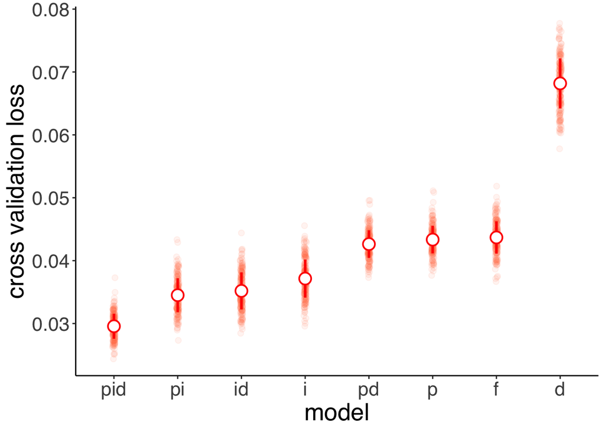

```r
ggplot(data = df.losses,
       mapping = aes(
         x = model %>% reorder(B_losses),
         y = B_losses
       )) +
  geom_point(alpha = 0.08,
             color = "coral",
             position = position_jitter(width = 0.02, height = 0),
             size = 2) +
  stat_summary(fun = ~ mean(.),
               fun.min = ~ mean(.) - sd(.),
               fun.max = ~ mean(.) + sd(.),
               # fun.args = list(conf.int=.99),
               geom = "pointrange",
               shape = 21,
               size = 1,
               fill = "white",
               color = "red") +
  labs(x = "model", y = "cross validation loss")
```

# 7 Postprocessing

## 7.1 Regressing to responsibility

- regress prediction to responsibility, ONLY for experiments 1 and 2

```r
# isolate hsm and features predictions on exp/trial basis
df.tmp = df.exp123.master %>%
  select(exp, trial, hsm = any_of(xval_bestmodel)) %>%
  mutate(features = df.exp123.regression$fit123) %>%
  group_by(exp, trial) %>%
  mutate(n_bricks = 1) %>%
  summarize(across(c(hsm, features, n_bricks), sum), .groups = "drop") %>%
  filter(exp < 3)

# do regressions
exp1.pr_regression = df.exp123.trials %>%
  filter(exp == 1) %>%
  mutate(p_mean = p_mean / n_bricks) %>%
  lm(r_mean ~ p_mean, data = .)

exp2.pr_regression = df.exp123.trials %>%
  filter(exp == 2) %>%
  mutate(p_mean = p_mean / n_bricks) %>%
  lm(r_mean ~ p_mean, data = .)

# predict regressions
df.exp1.pr_regression = df.tmp %>%
  filter(exp == 1) %>%
  mutate(r_hsm =
           predict(exp1.pr_regression,
                   df.tmp %>%
                     filter(exp == 1) %>%
                     mutate(p_mean = hsm / n_bricks))) %>%
  mutate(r_features =
           predict(exp1.pr_regression,
                   df.tmp %>%
                     filter(exp == 1) %>%
                     mutate(p_mean = features / n_bricks))) %>%
  mutate(r_prediction_low =
           predict(exp1.pr_regression,
                   df.exp123.trials %>%
                     filter(exp == 1) %>%
                     mutate(p_mean = p_low / n_bricks))) %>%
  mutate(r_prediction_high =
           predict(exp1.pr_regression,
                   df.exp123.trials %>%
                     filter(exp == 1) %>%
                     mutate(p_mean = p_high / n_bricks))) %>%
  mutate(r_prediction_mean = exp1.pr_regression$fitted.values)
df.exp2.pr_regression = df.tmp %>%
  filter(exp == 2) %>%
  mutate(r_hsm =
           predict(exp2.pr_regression,
                   df.tmp %>%
                     filter(exp == 2) %>%
                     mutate(p_mean = hsm / n_bricks))) %>%
  mutate(r_features =
           predict(exp2.pr_regression,
                   df.tmp %>%
                     filter(exp == 2) %>%
                     mutate(p_mean = features / n_bricks))) %>%
  mutate(r_prediction_low =
           predict(exp2.pr_regression,
                   df.exp123.trials %>%
                     filter(exp == 2) %>%
                     mutate(p_mean = p_low / n_bricks))) %>%
  mutate(r_prediction_high =
           predict(exp2.pr_regression,
                   df.exp123.trials %>%
                     filter(exp == 2) %>%
                     mutate(p_mean = p_high / n_bricks))) %>%
  mutate(r_prediction_mean = exp2.pr_regression$fitted.values)

# combine regressions
df.exp12.pr_regression = bind_rows(
  df.exp1.pr_regression,
  df.exp2.pr_regression,
  .id = "exp") %>%
  mutate(exp = as.numeric(exp)) %>%
  left_join(df.exp12.trials %>%
              select(exp, trial, r_mean, r_low, r_high, p_mean, p_low, p_high),
              by = c("trial", "exp"))
```

## 7.2 Model accuracy

```r
df.exp123.master %>%
  select(exp, trial, response, fall = "hsm_0,0,0", hsm = any_of(xval_bestmodel)) %>%
  mutate(acc = ifelse(fall == 0, 1 - hsm, hsm)) %>%
  group_by(exp) %>%
  summarize(mean(acc))

df.exp123.master %>%
  select(exp, trial, response, fall = "hsm_0,0,0", hsm = any_of(xval_bestmodel)) %>%
  mutate(acc = ifelse(fall == 0, 1 - hsm, hsm)) %>%
  group_by(fall, exp) %>%
  summarize(mean(acc))

df.exp123.regression %>%
  select(exp, trial, response, features = fit123) %>%
  mutate(fall = df.exp123.master[["hsm_0,0,0"]]) %>%
  mutate(acc = ifelse(fall == 0, 1 - features, features)) %>%
  group_by(exp) %>%
  summarize(mean(acc))

df.exp123.regression %>%
  select(exp, trial, response, features = fit123) %>%
  mutate(fall = df.exp123.master[["hsm_0,0,0"]]) %>%
  mutate(acc = ifelse(fall == 0, 1 - features, features)) %>%
  group_by(fall, exp) %>%
  summarize(mean(acc))
```

```
# A tibble: 3 x 2
    exp `mean(acc)`
  <dbl>       <dbl>
1     1       0.794
2     2       0.809
3     3       0.632
# A tibble: 6 x 3
# Groups:   fall [2]
   fall   exp `mean(acc)`
  <dbl> <dbl>       <dbl>
1     0     1       0.826
2     0     2       0.857
3     0     3       0.606
4     1     1       0.633
5     1     2       0.620
6     1     3       0.683
# A tibble: 3 x 2
    exp `mean(acc)`
  <dbl>       <dbl>
1     1       0.723
2     2       0.743
3     3       0.622
# A tibble: 6 x 3
# Groups:   fall [2]
   fall   exp `mean(acc)`
  <dbl> <dbl>       <dbl>
1     0     1       0.773
2     0     2       0.819
3     0     3       0.617
4     1     1       0.470
5     1     2       0.452
6     1     3       0.630
```

# 8 Figures

- note: figure fonts may not render at proper size but they will save at proper size

## 8.1 Exp 1

### 8.1.1 stimuli examples

```r
# Read in brick information
json.location = "../../data/exp1/"
stimuli.location = "../../figures/stimuli/exp1/initial/"

filenames = list.files(json.location) %>% mixedsort
imagenames = list.files(stimuli.location) %>% mixedsort

for (i in 1:length(imagenames)) {
  df.plot = rjson::fromJSON(file = paste0(json.location, filenames[i])) %>%
    unlist() %>%
    matrix(ncol = 4, byrow = T) %>%
    as.data.frame(stringsAsFactors = F) %>%
    setNames(c("index", "x", "y", "angle")) %>%
    mutate(index = str_replace(index, "brick_", "")) %>%
    mutate(across(.cols = everything(), ~ as.numeric(.))) %>%
    mutate(across(c(x, y), ~ . * 100)) %>%
    mutate(y = 600 - y) %>%
    filter(x != -500) %>%
    mutate(e.x_1 = x - 40,
           e.y_1 = y + 20,
           e.x_2 = x + 40,
           e.y_2 = y + 20,
           e.x_3 = x + 40,
           e.y_3 = y - 20,
           e.x_4 = x - 40,
           e.y_4 = y - 20) %>%
    left_join(df.exp1.info %>% filter(trial == i) %>% select(index, fall)) %>%
    wideToLong(within = 'edge') %>%
    mutate(e.xt = x - e.x,
           e.yt = y - e.y,
           angle = -angle,
           e.xr = e.xt * cos(angle) - e.yt * sin(angle),
           e.yr = e.yt * cos(angle) + e.xt * sin(angle),
           e.xrm = e.xr + x,
           e.yrm = e.yr + y
    ) %>%
    arrange(index, edge) %>%
    filter(index != 0)

  df.plot = df.plot %>%
    arrange(fall)
  image = png::readPNG(paste0(stimuli.location, imagenames[i]))
  p = ggplot(df.plot) +
    annotation_custom(rasterGrob(image,
                                 width = unit(1, "npc"),
                                 height = unit(1, "npc")),
                      xmin = 0, xmax = 800, ymin = 0, ymax = 600) +
    scale_x_continuous(expand = c(0, 0), limits = c(0, 800)) +
    scale_y_continuous(expand = c(0, 0), limits = c(0, 600)) +
    scale_color_manual(values = c("black", "red")) +
    theme_void() +
    theme(axis.ticks.length = unit(0.001, "mm"),
          legend.position = 'none')

  for (j in unique(df.plot$index)) {
    fall = df.plot %>% filter(index == j) %>% filter(row_number() == 1) %>% pull(fall)
    if (i != 5 && fall == 1) {
      p = p +
        geom_polygon(data = df.plot %>% filter(index == j),
                     aes(x = e.xrm, y = e.yrm, color = "red"),
                     alpha = 0, linetype = 1, size = 1.5)
    } else {
      p = p +
        geom_polygon(data = df.plot %>% filter(index == j),
                     aes(x = e.xrm, y = e.yrm, color = "black"),
                     alpha = 0, linetype = 1, size = 1.5)
    }
  }

  print(p)
  img.name = paste0("../../figures/plots/exp1/stimuli_truth/", i, ".png")
  ggsave(img.name, width = 8, height = 6, dpi = 100)
  tmp = image_read(img.name)
  tmp = image_crop(tmp, "400x550+200+50")
  image_write(tmp, path = img.name, format = "png")
}
```

- creating stimuli images

```r
ids = c(1, 8, 14, 22, 31, 41, 5)

for (i in 1:length(ids)) {
    id = ids[i]
    img = image_read(paste0("../../figures/plots/exp1/stimuli_truth/", id, ".png"))
    img = ggplot() + background_image(img) + theme_void() + coord_fixed(ratio = 4/3) +
      theme(panel.border = element_rect(colour = "black", fill=NA, size=2),
            plot.margin = unit(c(0,0,0,3), "pt"),
            plot.tag.position = c(0.11, 0.92))
  if (i == 1) {
    row = img
  } else {
    row = row | img
  }
}

row +
  plot_annotation(tag_levels = 'a', tag_suffix = ")")

ggsave("../../figures/plots/exp1/exp1_stimuli.pdf", width = 9.5,height = 2)
```

### 8.1.2 selection examples

```r
# brick size: 80 x 40

# Read in brick information
json.location = "../../data/exp1/"
stimuli.location = "../../figures/stimuli/exp1/"

filenames = list.files(json.location) %>% mixedsort
imagenames = list.files(stimuli.location) %>% mixedsort

# use the appropriate left-join line
# modelname = "hsm"
modelname = "feat"
# modelname = "people"
df.exp1.percentages = df.exp1.selection.brick %>%
  # left_join(df.exp1.model %>% select(trial, index, model = one_of(xval_bestmodel))) %>%
  mutate(model = df.exp123.regression %>% filter(exp == 1) %>% pull(fit123)) %>%
  # rename(model = response) %>%
  mutate(model = model * 100)

df.tmp = df.exp1.trials %>%
  select(trial, responsibility = r_mean, prediction = p_mean)

for (i in 1:length(imagenames)) {
# for (i in 1:5) {
  if (i == 5) next
  df.plot = rjson::fromJSON(file = paste0(json.location, filenames[i])) %>%
    unlist() %>%
    matrix(ncol = 4, byrow = T) %>%
    as.data.frame(stringsAsFactors = F) %>%
    setNames(c("index", "x", "y", "angle")) %>%
    mutate(index = str_replace(index, "brick_", "")) %>%
    mutate(across(.cols = everything(),
                  .fns = ~ as.numeric(.))) %>%
    mutate(across(.cols = c(x, y),
                  .fns = ~ . * 100)) %>%
    mutate(y = 600 - y) %>%
    filter(x != -500) %>%
    mutate(e.x_1 = x - 40,
           e.y_1 = y + 20,
           e.x_2 = x + 40,
           e.y_2 = y + 20,
           e.x_3 = x + 40,
           e.y_3 = y - 20,
           e.x_4 = x - 40,
           e.y_4 = y - 20) %>%
    left_join(df.exp1.percentages %>% filter(trial == i) %>% select(index, model)) %>%
    left_join(df.exp1.info %>% filter(trial == i) %>% select(index, fall)) %>%
    mutate(selection = round(model, 0)) %>%
    select(-model) %>%
    wideToLong(within = 'edge') %>%
    mutate(e.xt = x - e.x,
           e.yt = y - e.y,
           angle = -angle,
           e.xr = e.xt * cos(angle) - e.yt * sin(angle),
           e.yr = e.yt * cos(angle) + e.xt * sin(angle),
           e.xrm = e.xr + x,
           e.yrm = e.yr + y
    ) %>%
    arrange(index, edge) %>%
    filter(index != 0)

  df.text = df.plot %>%
    select(index, x, y, selection) %>%
    distinct()

  image = png::readPNG(paste0(stimuli.location, imagenames[i]))
  p = ggplot(df.plot) +
    annotation_custom(rasterGrob(image,
                                 width = unit(1, "npc"),
                                 height = unit(1, "npc")),
                      xmin = 0, xmax = 800, ymin = 0, ymax = 600) +
    scale_x_continuous(expand = c(0, 0), limits = c(0, 800)) +
    scale_y_continuous(expand = c(0, 0), limits = c(0, 600)) +
    # scale_fill_gradient(low = 'white', high = 'red', limits = c(0, 100)) +
    scale_alpha_continuous(range = c(min(df.plot$selection/100),
                                     max(df.plot$selection/100))) +
    scale_color_manual(values = c("black", "red")) +
    theme_void() +
    theme(axis.ticks.length = unit(0.001, "mm"),
          legend.position = 'none')

  if (modelname == "people") {
    p = p +
      geom_text(data = df.tmp %>%
                  filter(trial == i) %>%
                  mutate(pred_text = paste0("prediction: ",
                                            as.character(round(prediction, 1)),
                                            " bricks")),
                mapping = aes(x = 220,
                              y = 520,
                              hjust = 0,
                              label = pred_text),
                size = 8) +
      geom_text(data = df.tmp %>%
                    filter(trial == i) %>%
                    mutate(resp_text = paste0("responsibility: ",
                                              as.character(round(responsibility, 0)))),
                mapping = aes(x = 220,
                              y = 480,
                              hjust = 0,
                              label = resp_text),
                size = 8)
  }

  # make sure red-bordered blocks are drawn after black-bordered blocks
  df.plot = df.plot %>%
    arrange(fall)

  for (j in unique(df.plot$index)) {
    p = p +
      geom_polygon(data = df.plot %>% filter(index == j),
                   aes(x = e.xrm, y = e.yrm, alpha=selection/100, color = as.factor(fall)),
                   fill = "white",
                   linetype = 1, size = 1.5) +
      geom_text(data = df.text %>%
                  filter(index == j), aes(x = x, y = y, label = selection), size = 7)
  }
  print(p)
  img.name = paste0("../../figures/plots/exp1/stimuli_percentages/",i, "_",modelname,".png")
  ggsave(img.name, width = 8, height = 6, dpi = 100)
  tmp = image_read(img.name)
  tmp = image_crop(tmp, "400x550+200+50")
  image_write(tmp, path = img.name, format = "png")
}
```

- create sample array

```r
ids = c(18, 24, 2, 25, 27)
labels = c("a)", "b)", "c)", "d)", "e)")

label_hsm = ggplot() + theme_void() + ylab("CSM") +
  theme(axis.title.y.left = element_text(face = "bold", size = 18, angle = 90))
label_feat = ggplot() + theme_void() + ylab("features model") +
  theme(axis.title.y.left = element_text(face = "bold", size = 18, angle = 90))
label_ppl = ggplot() + theme_void() + ylab("people") +
  theme(axis.title.y.left = element_text(face = "bold", size = 18, angle = 90))

combo_img = (label_hsm / label_feat / label_ppl)

for (i in 1:length(ids)) {
  id = ids[[i]]
  img_hsm = image_read(paste0('../../figures/plots/exp1/stimuli_percentages/',
                              id,'_hsm.png'))
  img_feat = image_read(paste0('../../figures/plots/exp1/stimuli_percentages/',
                               id,'_feat.png'))
  img_ppl = image_read(paste0('../../figures/plots/exp1/stimuli_percentages/',
                              id,'_people.png'))
  img_hsm = ggplot() + background_image(img_hsm) + theme_void() +
    coord_fixed(ratio = 4/3) + ggtitle(labels[[i]]) +
    theme(plot.title = element_text(face = "bold", size = 20, vjust = -5, hjust = 0.06),
          axis.title.y.left = element_text(face = "bold", size = 10, angle = 90))
  img_feat = ggplot() + background_image(img_feat) + coord_fixed(ratio = 4/3) +
    theme_void() + theme(plot.margin = unit(c(10,10,10,0), "pt"))
  img_ppl = ggplot() + background_image(img_ppl)  + coord_fixed(ratio = 4/3) +
    theme_void()

  img = (img_hsm / img_feat / img_ppl)

  combo_img = combo_img | img
}

combo_img + plot_layout(widths = c(0.05, 1, 1, 1, 1, 1))

ggsave("../../figures/plots/exp1/exp1_samples.pdf", width = 10,height = 8)
```

### 8.1.3 responses vs models

[figure not shown]

```r
# SELECTION

df.plot = df.exp1.master %>%
  select(trial, index, response, hsm = any_of(xval_bestmodel)) %>%
  left_join(df.exp123.regression %>%
              filter(exp == 1) %>%
              select(trial, index, features = fit123),
            by = c("trial", "index"))

# hsm model
plot.hsm_selection = ggplot(data = df.plot, mapping = aes(x = hsm, y = response)) +
  geom_abline(intercept = 0, slope = 1, linetype='dashed') +
  geom_smooth(method='lm', color='lightskyblue', fill='lightblue1') +
  geom_point(size=2.5, alpha = 0.4) +
  annotate(geom = "text", x=0,y=Inf,
           label = paste0("r = ", cor(df.plot$response,df.plot$hsm) %>% round(2)),
           hjust = 0, vjust = 1, size = 8)+
  annotate(geom = "text", x=0,y=Inf,
           label = paste0("RMSE = ", rmse(df.plot$response,df.plot$hsm) %>% round(2)),
           hjust = 0, vjust = 2.5, size = 8) +
  scale_x_continuous(breaks = seq(0, 1, .25),
                     labels = str_c(seq(0, 100, 25), "%"), limits = c(0, 1.05)) +
  scale_y_continuous(breaks = seq(0, 1, .25),
                     labels = str_c(seq(0, 100, 25), "%"), limits = c(0, 1.2)) +
  labs(x = "CSM",
       y = "selection probability",
       tag = "a)") +
  theme(axis.title.x = element_text(margin = margin(t = 10)),
        plot.tag = element_text(face = "bold"))

# features model
plot.features_selection = ggplot(data = df.plot,
                                 mapping = aes(x = features, y = response)) +
  geom_smooth(method='lm', color='lightskyblue', fill="lightblue1") +
  geom_point(size=2.5, alpha = 0.5) +
  geom_abline(intercept = 0, slope = 1, linetype='dashed') +
  annotate(geom = "text", x=0,y=Inf,
           label = paste0("r = ", cor(df.plot$response,df.plot$features) %>% round(2)),
           hjust = 0, vjust = 1, size = 8)+
  annotate(geom = "text", x=0,y=Inf,
           label = paste0("RMSE = ", rmse(df.plot$response,df.plot$features) %>% round(2)),
           hjust = 0, vjust =2.5, size = 8) +
  scale_x_continuous(breaks = seq(0, 1, .25),
                     labels = str_c(seq(0, 100, 25), "%"), limits = c(0, 1.05)) +
  scale_y_continuous(breaks = seq(0, 1, .25),
                     labels = str_c(seq(0, 100, 25), "%"), limits = c(0, 1.2)) +
  labs(x = "features model",
       y = "selection probability",
       tag = "d)") +
  theme(axis.title.x = element_text(margin = margin(t = 10)),
        plot.tag = element_text(face = "bold"))


# PREDICTION

df.plot = df.exp12.pr_regression %>%
  filter(exp == 1) %>%
  select(hsm, features, mean = p_mean, low = p_low, high = p_high)

# hsm model
plot.hsm_prediction = ggplot(df.plot, aes(x = hsm, y = mean)) +
  geom_abline(intercept = 0, slope = 1, linetype = 2) +
  stat_smooth(method = "lm", color = "lightskyblue", fill='lightblue1') +
  geom_errorbar(aes(ymin = low, ymax = high), width = 0, color='grey70') +
  geom_point(size = 2, color='black') +
  annotate(geom = "text",
           label = str_c("r = ", cor(df.plot$hsm, df.plot$mean) %>% round(2)),
           x = .2, y = Inf, hjust = 0, vjust = 1, size = 8) +
  annotate(geom = "text",
           label = str_c("RMSE = ", rmse(df.plot$hsm, df.plot$mean) %>% round(2)),
           x = .2, y = Inf, hjust = 0, vjust = 2.5, size = 8) +
  labs(x = "CSM", y = "prediction judgment", tag = "b)") +
  scale_x_continuous(breaks = seq(0, 8, 2), labels = seq(0, 8, 2), limits = c(0, 8)) +
  scale_y_continuous(breaks = seq(0, 8, 2), labels = seq(0, 8, 2), limits = c(0, 9)) +
  theme(panel.grid = element_blank(), plot.tag = element_text(face = "bold"))

# features model
plot.features_prediction = ggplot(df.plot, aes(x = features, y = mean)) +
  geom_abline(intercept = 0, slope = 1, linetype = 2) +
  stat_smooth(method = "lm", color = "lightskyblue", fill='lightblue1') +
  geom_errorbar(aes(ymin = low, ymax = high), width = 0, color='grey70') +
  geom_point(size = 2, color='black') +
  annotate(geom = "text",
           label = str_c("r = ", cor(df.plot$features, df.plot$mean) %>% round(2)),
           x = .2, y = Inf, hjust = 0, vjust = 1.5, size = 8) +
  annotate(geom = "text",
           label = str_c("RMSE = ", rmse(df.plot$features, df.plot$mean) %>% round(2)),
           x = .2, y = Inf, hjust = 0, vjust = 3, size = 8) +
  labs(x = "features model", y = "prediction judgment", tag = "e)") +
  scale_x_continuous(breaks = seq(0, 8, 2), labels = seq(0, 8, 2), limits = c(0, 8)) +
  scale_y_continuous(breaks = seq(0, 8, 2), labels = seq(0, 8, 2), limits = c(0, 9)) +
  theme(panel.grid = element_blank(), plot.tag = element_text(face = "bold"))


# RESPONSIBILITY

df.plot = df.exp12.pr_regression %>%
  filter(exp == 1) %>%
  select(hsm = r_hsm, features = r_features, mean = r_mean, low = r_low, high = r_high)

# hsm model
plot.hsm_responsibility = ggplot(df.plot, aes(x = hsm, y = mean)) +
  geom_abline(intercept = 0, slope = 1, linetype='dashed') +
  stat_smooth(method = "lm", color = "lightskyblue", fill='lightblue1') +
  geom_errorbar(aes(ymin = low, ymax = high), width = 0, color='grey70') +
  geom_point(size = 2, color='black') +
  annotate(geom = "text",
           label = str_c("r = ", cor(df.plot$hsm, df.plot$mean) %>% round(2)),
           x = 0, y = Inf, hjust = 0, vjust = 1, size = 8) +
  annotate(geom = "text",
           label = str_c("RMSE = ", rmse(df.plot$hsm, df.plot$mean) %>% round(2)),
           x = 0, y = Inf, hjust = 0, vjust = 2.5, size = 8) +
  labs(x = "CSM", y = "responsibility judgment", tag = "c)") +
  scale_x_continuous(breaks = seq(0, 100, 25), limits = c(0, 105)) +
  scale_y_continuous(breaks = seq(0, 100, 25), limits = c(0, 120)) +
  theme(panel.grid = element_blank(), plot.tag = element_text(face = "bold"))

# features model
plot.features_responsibility = ggplot(df.plot, aes(x = features, y = mean)) +
  geom_abline(intercept = 0, slope = 1, linetype='dashed') +
  stat_smooth(method = "lm", color = "lightskyblue", fill='lightblue1') +
  geom_errorbar(aes(ymin = low, ymax = high), width = 0, color='grey70') +
  geom_point(size = 2, color='black') +
  annotate(geom = "text",
           label = str_c("r = ", cor(df.plot$features, df.plot$mean) %>% round(2)),
           x = 0, y = Inf, hjust = 0, vjust = 1, size = 8) +
  annotate(geom = "text",
           label = str_c("RMSE = ", rmse(df.plot$features, df.plot$mean) %>% round(2)),
           x = 0, y = Inf, hjust = 0, vjust = 2.5, size = 8) +
  labs(x = "features model", y = "responsibility judgment", tag = "f)") +
  scale_x_continuous(breaks = seq(0, 100, 25), limits = c(0, 105)) +
  scale_y_continuous(breaks = seq(0, 100, 25), limits = c(0, 120)) +
  theme(panel.grid = element_blank(), plot.tag = element_text(face = "bold"))

# FIGURE

col1 <- ggplot() + annotate(geom = 'text', x=-5, y=0, label="Selection",
                            size=9, fontface = "bold" ) + theme_void()
col2 <- ggplot() + annotate(geom = 'text', x=0, y=0, label="Prediction",
                            size=9, fontface = "bold") + theme_void()
col3 <- ggplot() + annotate(geom = 'text', x=0, y=0, label="Responsibility",
                            size=9, fontface = "bold") + theme_void()

(col1 / plot.hsm_selection / plot.features_selection) +
  plot_layout(heights = c(0.15, 1, 1)) |
  (col2 / plot.hsm_prediction / plot.features_prediction) +
  plot_layout(heights = c(0.15, 1, 1)) |
  (col3 / plot.hsm_responsibility / plot.features_responsibility) +
  plot_layout(heights = c(0.15, 1, 1))
ggsave("../../figures/plots/exp1/exp1_plots.pdf", width = 15, height = 10)
```

### 8.1.4 selection to responsibility

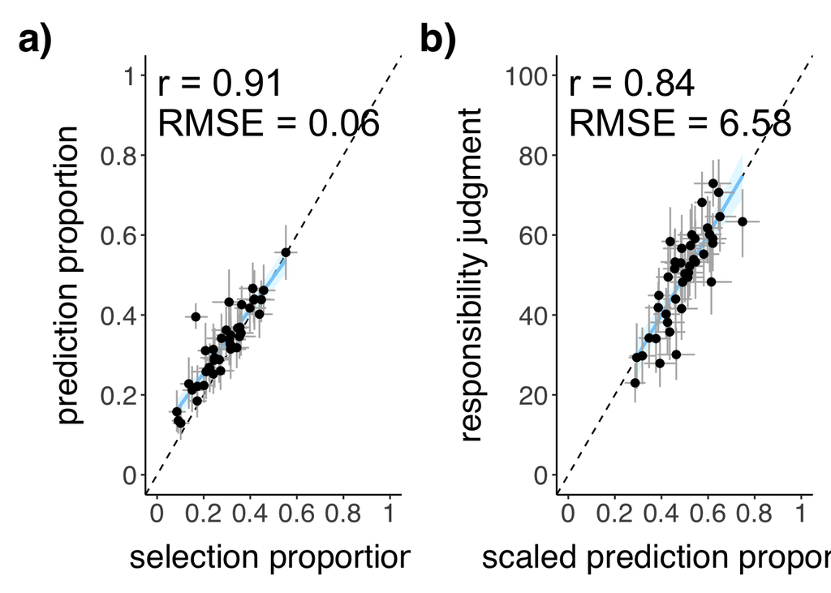

```r
# selection vs prediction
df.plot = df.exp1.selection.long %>%
  group_by(participant, trial) %>%
  summarize(s_pred = sum(response), .groups = "drop") %>%
  group_by(trial) %>%
  summarize(s_mean = mean(s_pred),
            s_low = smean.cl.boot(s_pred)[2],
            s_high = smean.cl.boot(s_pred)[3]) %>%
  left_join(df.exp1.trials %>%
    select(trial, p_mean, p_low, p_high, r_mean, r_low, r_high, n_bricks),
    by = "trial") %>%
  mutate(sp_mean = s_mean/n_bricks, sp_low = s_low/n_bricks, sp_high = s_high/n_bricks,
         pp_mean = p_mean/n_bricks, pp_low = p_low/n_bricks, pp_high = p_high/n_bricks)

plot.selection_prediction = ggplot(df.plot, aes(x = sp_mean, y = pp_mean)) +
  geom_abline(intercept = 0, slope = 1, linetype = 2) +
  geom_smooth(method = "lm", color = "lightskyblue", fill='lightblue1') +
  geom_errorbarh(aes(xmin = sp_low, xmax = sp_high), height = 0, color='grey70') +
  geom_errorbar(aes(ymin = pp_low, ymax = pp_high), width = 0, color='grey70') +
  geom_point(size = 2, color='black') +
  annotate(geom = "text",
           label = str_c("r = ", cor(df.plot$sp_mean, df.plot$pp_mean) %>% round(2)),
           x = 0, y = Inf, hjust = 0, vjust = 1.5, size = 8) +
  annotate(geom = "text",
           label = str_c("RMSE = ", rmse(df.plot$sp_mean, df.plot$pp_mean) %>% round(2)),
           x = 0, y = Inf, hjust = 0, vjust = 3, size = 8) +
  # annotate(geom = "text", label = "", x = 0, y = 0, hjust = 0) +
  labs(x = "selection proportion", y = "prediction proportion") +
  # coord_cartesian(ylim = c(0, NA), xlim = c(0, NA)) +
  scale_x_continuous(breaks = seq(0, 1, .2), labels = seq(0, 1, .2), limits = c(0, 1)) +
  scale_y_continuous(breaks = seq(0, 1, .2), labels = seq(0, 1, .2), limits = c(0, 1)) +
  theme(text = element_text(size = 20),
        panel.grid = element_blank(),
        axis.title.x = element_text(margin = margin(t = 10)),
        axis.title.y = element_text(margin = margin(r = 10)))

df.plot2 = df.exp12.pr_regression %>%
  filter(exp == 1) %>%
  mutate(across(contains("r_prediction"), ~./100))

# selection vs responsibility
plot.prediction_responsibility = ggplot(df.plot2,
                                        aes(x = r_prediction_mean, y = r_mean)) +
  geom_abline(intercept = 0, slope = 100, linetype = 2) +
  geom_smooth(method = "lm", color = "lightskyblue", fill="lightblue1") +
  geom_errorbarh(aes(xmin = r_prediction_low, xmax = r_prediction_high),
                 height = 0, color="grey70") +
  geom_errorbar(aes(ymin = r_low, ymax = r_high), width = 0, color="grey70") +
  geom_point(size = 2, color="black") +
  annotate(geom = "text",
           label = str_c("r = ", cor(df.plot2$r_mean, df.plot2$r_prediction_mean)
                         %>% round(2)),
           x = 0, y = Inf, hjust = 0, vjust = 1.5, size = 8) +
  annotate(geom = "text",
           label = str_c("RMSE = ", rmse(df.plot2$r_mean, df.plot2$r_prediction_mean*100)
                         %>% round(2)),
           x = 0, y = Inf, hjust = 0, vjust = 3, size = 8) +
  labs(x = "scaled prediction proportion", y = "responsibility judgment") +
  scale_x_continuous(breaks = seq(0, 1, .2),
                     labels = seq(0, 1, .2), limits = c(0, 1)) +
  scale_y_continuous(breaks = seq(0, 100, 20),
                     labels = seq(0, 100, 20), limits = c(0, 100)) +
  # coord_cartesian(xlim = c(0, 0.65), ylim = c(0, 0.9)) +
  theme(text = element_text(size = 20),
        panel.grid = element_blank(),
        axis.title.x = element_text(margin = margin(t = 10)),
        axis.title.y = element_text(margin = margin(r = 10)))

plot.selection_prediction + plot.prediction_responsibility +
  plot_annotation(tag_levels = "a", tag_suffix = ")") &
  theme(plot.tag = element_text(face = 'bold'))
ggsave("../../figures/plots/exp1/exp1_selection_responsibility.pdf",width = 12,height = 6)
```

## 8.2 Exp 2

### 8.2.1 stimuli examples

```r
# Read in brick information
json.location = "../../data/exp2/"
stimuli.location = "../../figures/stimuli/exp2/"

filenames = list.files(json.location) %>% mixedsort()
imagenames = list.files(stimuli.location) %>% mixedsort

for (i in 1:length(imagenames)) {
  df.plot = rjson::fromJSON(file = paste0(json.location, filenames[i])) %>%
    unlist() %>%
    matrix(ncol = 4, byrow = T) %>%
    as.data.frame(stringsAsFactors = F) %>%
    setNames(c("index", "x", "y", "angle")) %>%
    mutate(index = str_replace(index, "brick_", "")) %>%
    mutate(across(.cols = everything(),
                  .fns = ~ as.numeric(.))) %>%
    mutate(across(.cols = c(x, y),
                  .fns = ~ . * 100)) %>%
    mutate(y = 600 - y) %>%
    filter(x != -500) %>%
    mutate(e.x_1 = x - 40,
           e.y_1 = y + 20,
           e.x_2 = x + 40,
           e.y_2 = y + 20,
           e.x_3 = x + 40,
           e.y_3 = y - 20,
           e.x_4 = x - 40,
           e.y_4 = y - 20) %>%
    left_join(df.exp2.info %>% filter(trial == i) %>% select(index, fall)) %>%
    wideToLong(within = 'edge') %>%
    mutate(e.xt = x - e.x,
           e.yt = y - e.y,
           angle = -angle,
           e.xr = e.xt * cos(angle) - e.yt * sin(angle),
           e.yr = e.yt * cos(angle) + e.xt * sin(angle),
           e.xrm = e.xr + x,
           e.yrm = e.yr + y
    ) %>%
    arrange(index, edge) %>%
    filter(index != 0)

  image = png::readPNG(paste0(stimuli.location, imagenames[i]))
  p = ggplot(df.plot) +
    annotation_custom(rasterGrob(image,
                                 width = unit(1, "npc"),
                                 height = unit(1, "npc")),
                      xmin = 0, xmax = 800, ymin = 0, ymax = 600) +
    scale_x_continuous(expand = c(0, 0), limits = c(0, 800)) +
    scale_y_continuous(expand = c(0, 0), limits = c(0, 600)) +
    scale_color_manual(values = c("black", "red")) +
    theme_void() +
    theme(axis.ticks.length = unit(0.001, "mm"),
          legend.position = 'none')

  df.plot = df.plot %>%
    arrange(fall)
  for (j in unique(df.plot$index)) {
    fall = df.plot %>% filter(index == j) %>% filter(row_number() == 1) %>% pull(fall)
    if (fall == 1) {
      p = p +
        geom_polygon(data = df.plot %>% filter(index == j),
                     aes(x = e.xrm, y = e.yrm, color = "red"),
                     alpha = 0, linetype = 1, size = 1.5)
    } else if (fall == 0) {
      p = p +
        geom_polygon(data = df.plot %>% filter(index == j),
                     aes(x = e.xrm, y = e.yrm, color = "black"),
                     alpha = 0, linetype = 1, size = 1.5)
    }
  }

  print(p)
  img.name = paste0("../../figures/plots/exp2/stimuli_truth/", i, ".png")
  ggsave(img.name, width = 8, height = 6, dpi = 100)
  tmp = image_read(img.name)
  tmp = image_crop(tmp, "400x550+200+50")
  image_write(tmp, path = img.name, format = "png")
}
```

- creating stimuli images

```r
ids = list(c(10,12,14), c(16,19,20), c(36,42,38), c(24,25,27))
labels = c("I", "II", "III", "IV")
tags = c("a", "b", "c", "d", "e", "f", "g", "h", "i", "j", "k", "l")

for (i in 1:length(ids)) {
  tower = ggplot() + theme_void() + ylab(paste0("Tower ", labels[i])) +
    theme(axis.title.y.left = element_text(face = "bold", size = 18, angle = 90),
          plot.margin = unit(c(0,0,0,10), "pt"))
  for (j in 1:length(ids[[i]])) {
    id = ids[[i]][[j]]
    img = image_read(paste0("../../figures/plots/exp2/stimuli_truth/", id, ".png"))
    img = ggplot() + background_image(img) + theme_void() + coord_fixed(ratio = 4/3) +

      labs(title = paste0(tags[[(i-1)*3+j]], ")")) +
      theme(panel.border = element_rect(colour = "black", fill=NA, size=2),
            plot.margin = unit(c(0,0,0,3), "pt"),
            plot.title = element_text(size = 15, vjust = -4.7, hjust = 0.11),
            plot.title.position = "panel")
    tower = tower | img
  }

  if (i %% 2 == 1) {
    row = tower + plot_layout(widths = c(0.05, 1, 1, 1))
  } else {
    tower = tower + plot_layout(widths = c(0.05, 1, 1, 1))
    row = row - tower
    if (i == 2) {
      rows = row
    } else if (i == 4) {
      rows = rows / row
    }
  }
}

rows

ggsave("../../figures/plots/exp2/exp2_stimuli.pdf", width = 9.5,height = 4)
```

### 8.2.2 selection examples

```r
# Read in brick information
json.location = "../../data/exp2/"
stimuli.location = "../../figures/stimuli/exp2/"

filenames = list.files(json.location) %>% mixedsort
imagenames = list.files(stimuli.location) %>% mixedsort

# use the appropriate left-join line
# modelname = "hsm"
modelname = "feat"
# modelname = "people"
df.exp2.percentages = df.exp2.selection.brick %>%
  # left_join(df.exp2.model %>% select(trial, index, model = one_of(xval_bestmodel))) %>%
  mutate(model = df.exp123.regression %>% filter(exp == 2) %>% pull(fit123)) %>%
  # rename(model = response) %>%
  mutate(model = model * 100)

df.tmp = df.exp2.trials %>%
  select(trial, responsibility = r_mean, prediction = p_mean)

for (i in 1:length(imagenames)) {
  df.plot = rjson::fromJSON(file = paste0(json.location, filenames[i])) %>%
    unlist() %>%
    matrix(ncol = 4, byrow = T) %>%
    as.data.frame(stringsAsFactors = F) %>%
    setNames(c("index", "x", "y", "angle")) %>%
    mutate(index = str_replace(index, "brick_", "")) %>%
    mutate(across(.cols = everything(),
                  .fns = ~ as.numeric(.))) %>%
    mutate(across(.cols = c(x, y),
                  .fns = ~ . * 100)) %>%
    mutate(y = 600 - y) %>%
    filter(x != -500) %>%
    mutate(e.x_1 = x - 40,
           e.y_1 = y + 20,
           e.x_2 = x + 40,
           e.y_2 = y + 20,
           e.x_3 = x + 40,
           e.y_3 = y - 20,
           e.x_4 = x - 40,
           e.y_4 = y - 20) %>%
    left_join(df.exp2.percentages %>% filter(trial == i) %>% select(index, model)) %>%
    left_join(df.exp2.info %>% filter(trial == i) %>% select(index, fall)) %>%
    mutate(selection = round(model, 0)) %>%
    select(-model) %>%
    wideToLong(within = 'edge') %>%
    mutate(e.xt = x - e.x,
           e.yt = y - e.y,
           angle = -angle,
           e.xr = e.xt * cos(angle) - e.yt * sin(angle),
           e.yr = e.yt * cos(angle) + e.xt * sin(angle),
           e.xrm = e.xr + x,
           e.yrm = e.yr + y
    ) %>%
    arrange(index, edge) %>%
    filter(index != 0)

  df.text = df.plot %>%
    select(index, x, y, selection) %>%
    distinct()

  image = png::readPNG(paste0(stimuli.location, imagenames[i]))
  p = ggplot(df.plot) +
    annotation_custom(rasterGrob(image,
                                 width = unit(1, "npc"),
                                 height = unit(1, "npc")),
                      xmin = 0, xmax = 800, ymin = 0, ymax = 600) +
    scale_x_continuous(expand = c(0, 0), limits = c(0, 800)) +
    scale_y_continuous(expand = c(0, 0), limits = c(0, 600)) +
    # scale_fill_gradient(low = 'white', high = 'red', limits = c(0, 100)) +
    scale_alpha_continuous(range = c(min(df.plot$selection/100),
                                     max(df.plot$selection/100))) +
    scale_color_manual(values = c("black", "red")) +
    theme_void() +
    theme(axis.ticks.length = unit(0.001, "mm"),
          legend.position = 'none')

  # add prediction and responsibility text to image
  if (modelname == "people") {
    p = p +
      geom_text(data = df.tmp %>%
                  filter(trial == i) %>%
                  mutate(pred_text = paste0("prediction: ",
                                            as.character(round(prediction, 1)),
                                            " bricks")),
                mapping = aes(x = 220,
                              y = 520,
                              hjust = 0,
                              label = pred_text),
                size = 8) +
      geom_text(data = df.tmp %>%
                    filter(trial == i) %>%
                    mutate(resp_text = paste0("responsibility: ",
                                              as.character(round(responsibility, 0)))),
                mapping = aes(x = 220,
                              y = 480,
                              hjust = 0,
                              label = resp_text),
                size = 8)
  }

  df.plot = df.plot %>%
    arrange(fall)
  for (j in unique(df.plot$index)) {
    p = p +
      geom_polygon(data = df.plot %>% filter(index == j),
                   aes(x = e.xrm, y = e.yrm, alpha = selection/100, color=as.factor(fall)),
                   fill = "white",
                   linetype = 1, size = 1.5) +
      geom_text(data = df.text %>% filter(index == j),
                aes(x = x, y = y, label = selection), size = 7)
  }
  print(p)
  img.name = paste0("../../figures/plots/exp2/stimuli_percentages/",i,"_",modelname,".png")
  ggsave(img.name, width = 8, height = 6, dpi = 100)
  tmp = image_read(img.name)
  tmp = image_crop(tmp, "400x550+200+50")
  image_write(tmp, path = img.name, format = "png")
}
```

[output not shown]

- create sample array

```r
ids = c(2, 6, 24, 35, 13)
labels = c("a)", "b)", "c)", "d)", "e)")

label_hsm = ggplot() + theme_void() + ylab("CSM") +
  theme(axis.title.y.left = element_text(face = "bold", size = 18, angle = 90))
label_feat = ggplot() + theme_void() + ylab("features model") +
  theme(axis.title.y.left = element_text(face = "bold", size = 18, angle = 90))
label_ppl = ggplot() + theme_void() + ylab("people") +
  theme(axis.title.y.left = element_text(face = "bold", size = 18, angle = 90))

combo_img = (label_hsm / label_feat / label_ppl)


for (i in 1:length(ids)) {
  id = ids[[i]]
  img_hsm = image_read(paste0('../../figures/plots/exp2/stimuli_percentages/',
                              id,'_hsm.png'))
  img_feat = image_read(paste0('../../figures/plots/exp2/stimuli_percentages/',
                               id,'_feat.png'))
  img_ppl = image_read(paste0('../../figures/plots/exp2/stimuli_percentages/',
                              id,'_people.png'))
  img_hsm = ggplot() + background_image(img_hsm) + theme_void() +
    coord_fixed(ratio=4/3) + ggtitle(labels[[i]]) +
    theme(plot.title = element_text(face = "bold", size = 20, vjust = -5, hjust = 0.06),
          axis.title.y.left = element_text(face = "bold", size = 10, angle = 90))
  img_feat = ggplot() + background_image(img_feat) + theme_void() +
    coord_fixed(ratio=4/3) + theme(plot.margin = unit(c(10,10,10,0), "pt"))
  img_ppl = ggplot() + background_image(img_ppl)  + theme_void() + coord_fixed(ratio=4/3)

  img = (img_hsm / img_feat / img_ppl)
  combo_img = combo_img | img
}

combo_img + plot_layout(widths = c(0.05, 1, 1, 1, 1, 1))

ggsave("../../figures/plots/exp2/exp2_samples.pdf",width = 10,height = 8)
```

[output not shown]

### 8.2.3 responses vs models

```
mapping: x = ~x, y = ~y
geom_text: na.rm = FALSE
stat_identity: na.rm = FALSE
position_identity
```

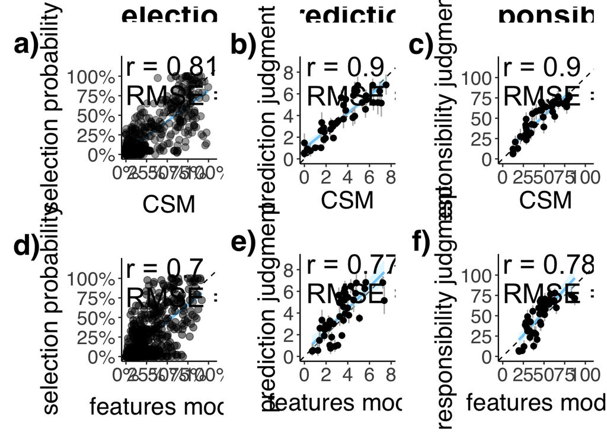

```r
# SELECTION

df.plot = df.exp2.master %>%
  select(trial, index, response, hsm = any_of(xval_bestmodel)) %>%
  left_join(df.exp123.regression %>%
              filter(exp == 2) %>%
              select(trial, index, features = fit123),
            by = c("trial", "index"))

# hsm model
plot.hsm_selection = ggplot(data = df.plot, mapping = aes(x = hsm, y = response)) +
  geom_abline(intercept = 0, slope = 1, linetype='dashed') +
  geom_smooth(method='lm', color='lightskyblue', fill='lightblue1') +
  geom_point(size=2.5, alpha = 0.4) +
  annotate(geom = "text", x=0,y=Inf,
           label = paste0("r = ", cor(df.plot$response,df.plot$hsm) %>% round(2)),
           hjust = 0, vjust = 1, size = 8)+
  annotate(geom = "text", x=0,y=Inf,
           label = paste0("RMSE = ", rmse(df.plot$response,df.plot$hsm) %>% round(2)),
         hjust = 0, vjust =2.5, size = 8) +
  scale_x_continuous(breaks = seq(0, 1, .25),
                     labels = str_c(seq(0, 100, 25), "%"), limits = c(0, 1.05)) +
  scale_y_continuous(breaks = seq(0, 1, .25),
                     labels = str_c(seq(0, 100, 25), "%"), limits = c(0, 1.2)) +
  labs(x = "CSM", y = "selection probability", tag = "a)") +
  theme(axis.title.x = element_text(margin = margin(t = 10)),
        plot.tag = element_text(face = "bold"))

# features model
plot.features_selection = ggplot(data = df.plot,
                                 mapping = aes(x = features, y = response)) +
  geom_smooth(method='lm', color='lightskyblue', fill="lightblue1") +
  geom_point(size=2.5, alpha = 0.5) +
  geom_abline(intercept = 0, slope = 1, linetype='dashed') +
  annotate(geom = "text", x=0,y=Inf,
           label = paste0("r = ", cor(df.plot$response,df.plot$features) %>% round(2)),
           hjust = 0, vjust = 1, size = 8)+
  annotate(geom = "text", x=0,y=Inf,
           label = paste0("RMSE = ", rmse(df.plot$response,df.plot$features) %>% round(2)),
         hjust = 0, vjust =2.5, size = 8) +
  scale_x_continuous(breaks = seq(0, 1, .25),
                     labels = str_c(seq(0, 100, 25), "%"), limits = c(0, 1.05)) +
  scale_y_continuous(breaks = seq(0, 1, .25),
                     labels = str_c(seq(0, 100, 25), "%"), limits = c(0, 1.2)) +
  labs(x = "features model", y = "selection probability", tag = "d)") +
  theme(axis.title.x = element_text(margin = margin(t = 10)),
        plot.tag = element_text(face = "bold"))


# PREDICTION

df.plot = df.exp12.pr_regression %>%
  filter(exp == 2) %>%
  select(hsm, features, mean = p_mean, low = p_low, high = p_high)

# hsm model
plot.hsm_prediction = ggplot(df.plot, aes(x = hsm, y = mean)) +
  geom_abline(intercept = 0, slope = 1, linetype = 2) +
  stat_smooth(method = "lm", color = "lightskyblue", fill='lightblue1') +
  geom_errorbar(aes(ymin = low, ymax = high), width = 0, color='grey70') +
  geom_point(size = 2, color='black') +
  annotate(geom = "text",
           label = str_c("r = ", cor(df.plot$hsm, df.plot$mean) %>% round(2)),
           x = .2, y = Inf, hjust = 0, vjust = 1, size = 8) +
  annotate(geom = "text",
           label = str_c("RMSE = ", rmse(df.plot$hsm, df.plot$mean) %>% round(2)),
           x = .2, y = Inf, hjust = 0, vjust = 2.5, size = 8) +
  labs(x = "CSM", y = "prediction judgment", tag = "b)") +
  scale_x_continuous(breaks = seq(0, 8, 2), limits = c(0, 8)) +
  scale_y_continuous(breaks = seq(0, 8, 2), limits = c(0, 9)) +
  theme(text = element_text(size = 20), panel.grid = element_blank(),
        plot.tag = element_text(face = "bold"))

# features model
plot.features_prediction = ggplot(df.plot, aes(x = features, y = mean)) +
  geom_abline(intercept = 0, slope = 1, linetype = 2) +
  stat_smooth(method = "lm", color = "lightskyblue", fill='lightblue1') +
  geom_errorbar(aes(ymin = low, ymax = high), width = 0, color='grey70') +
  geom_point(size = 2, color='black') +
  annotate(geom = "text",
           label = str_c("r = ", cor(df.plot$features, df.plot$mean) %>% round(2)),
           x = .2, y = Inf, hjust = 0, vjust = 1, size = 8) +
  annotate(geom = "text",
           label = str_c("RMSE = ", rmse(df.plot$features, df.plot$mean) %>% round(2)),
           x = .2, y = Inf, hjust = 0, vjust = 2.5, size = 8) +
  labs(x = "features model", y = "prediction judgment", tag = "e)") +
  scale_x_continuous(breaks = seq(0, 8, 2), limits = c(0, 8)) +
  scale_y_continuous(breaks = seq(0, 8, 2), limits = c(0, 9)) +
  theme(text = element_text(size = 20), panel.grid = element_blank(),
        plot.tag = element_text(face = "bold"))


# RESPONSIBILITY

df.plot = df.exp12.pr_regression %>%
  filter(exp == 2) %>%
  select(hsm = r_hsm, features = r_features, mean = r_mean, low = r_low, high = r_high)

# hsm model
plot.hsm_responsibility = ggplot(df.plot, aes(x = hsm, y = mean)) +
  geom_abline(intercept = 0, slope = 1, linetype='dashed') +
  stat_smooth(method = "lm", color = "lightskyblue", fill='lightblue1') +
  geom_errorbar(aes(ymin = low, ymax = high), width = 0, color='grey70') +
  geom_point(size = 2, color='black') +
  annotate(geom = "text",
           label = str_c("r = ", cor(df.plot$hsm, df.plot$mean) %>% round(2)),
           x = 0, y = Inf, hjust = 0, vjust = 1, size = 8) +
  annotate(geom = "text",
           label = str_c("RMSE = ", rmse(df.plot$hsm, df.plot$mean) %>% round(2)),
           x = 0, y = Inf, hjust = 0, vjust = 2.5, size = 8) +
  labs(x = "CSM", y = "responsibility judgment", tag = "c)") +
  scale_x_continuous(breaks = seq(0, 100, 25), limits = c(0, 105)) +
  scale_y_continuous(breaks = seq(0, 100, 25), limits = c(0, 120)) +
  theme(panel.grid = element_blank(), plot.tag = element_text(face = "bold"))
  annotate(geom = "text", label = "responsibility", x = 0, y = 0)

# features model
plot.features_responsibility = ggplot(df.plot, aes(x = features, y = mean)) +
  geom_abline(intercept = 0, slope = 1, linetype='dashed') +
  stat_smooth(method = "lm", color = "lightskyblue", fill='lightblue1') +
  geom_errorbar(aes(ymin = low, ymax = high), width = 0, color='grey70') +
  geom_point(size = 2, color='black') +
  annotate(geom = "text",
           label = str_c("r = ", cor(df.plot$features, df.plot$mean) %>% round(2)),
           x = 0, y = Inf, hjust = 0, vjust = 1, size = 8) +
  annotate(geom = "text",
           label = str_c("RMSE = ", rmse(df.plot$features, df.plot$mean) %>% round(2)),
           x = 0, y = Inf, hjust = 0, vjust = 2.5, size = 8) +
  labs(x = "features model", y = "responsibility judgment", tag = "f)") +
  scale_x_continuous(breaks = seq(0, 100, 25), limits = c(0, 105)) +
  scale_y_continuous(breaks = seq(0, 100, 25), limits = c(0, 120)) +
  theme(panel.grid = element_blank(), plot.tag = element_text(face = "bold"))

# FIGURE

col1 <- ggplot() +
  annotate(geom = 'text', x=-5, y=0, label="Selection", size=9, fontface = "bold" ) +
  theme_void()
col2 <- ggplot() +
  annotate(geom = 'text', x=0, y=0, label="Prediction", size=9, fontface = "bold") +
  theme_void()
col3 <- ggplot() +
  annotate(geom = 'text', x=0, y=0, label="Responsibility", size=9, fontface = "bold") +
  theme_void()

(col1 / plot.hsm_selection / plot.features_selection) +
  plot_layout(heights = c(0.15, 1, 1)) |
  (col2 / plot.hsm_prediction / plot.features_prediction) +
  plot_layout(heights = c(0.15, 1, 1)) |
  (col3 / plot.hsm_responsibility / plot.features_responsibility) +
  plot_layout(heights = c(0.15, 1, 1))
ggsave("../../figures/plots/exp2/exp2_plots.pdf", width = 15, height = 10)
```

### 8.2.4 selection to responsibility

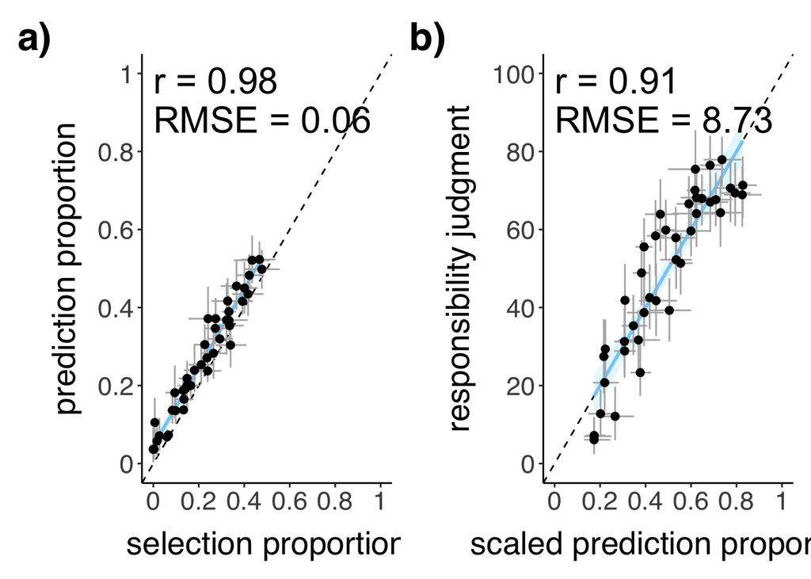

```r
df.plot = df.exp2.selection.long %>%
  group_by(participant, trial) %>%
  summarize(s_pred = sum(response), .groups = "drop") %>%
  group_by(trial) %>%
  summarize(s_mean = mean(s_pred),
            s_low = smean.cl.boot(s_pred)[2],
            s_high = smean.cl.boot(s_pred)[3]) %>%
  left_join(df.exp2.trials %>%
    select(trial, p_mean, p_low, p_high, r_mean, r_low, r_high, n_bricks),
    by = "trial") %>%
  mutate(sp_mean = s_mean/n_bricks, sp_low = s_low/n_bricks, sp_high = s_high/n_bricks,
         pp_mean = p_mean/n_bricks, pp_low = p_low/n_bricks, pp_high = p_high/n_bricks)

plot.selection_prediction = ggplot(df.plot, aes(x = sp_mean, y = pp_mean)) +
  geom_abline(intercept = 0, slope = 1, linetype = 2) +
  geom_smooth(method = "lm", color = "lightskyblue", fill='lightblue1') +
  geom_errorbarh(aes(xmin = sp_low, xmax = sp_high), height = 0, color='grey70') +
  geom_errorbar(aes(ymin = pp_low, ymax = pp_high), width = 0, color='grey70') +
  geom_point(size = 2, color='black') +
  annotate(geom = "text",
           label = str_c("r = ", cor(df.plot$sp_mean, df.plot$pp_mean) %>% round(2)),
           x = 0, y = Inf, hjust = 0, vjust = 1.5, size = 8) +
  annotate(geom = "text",
           label = str_c("RMSE = ", rmse(df.plot$sp_mean, df.plot$pp_mean) %>% round(2)),
           x = 0, y = Inf, hjust = 0, vjust = 3, size = 8) +
  labs(x = "selection proportion", y = "prediction proportion") +
  # coord_cartesian(ylim = c(0, NA), xlim = c(0, NA)) +
  scale_x_continuous(breaks = seq(0, 1, .2), labels = seq(0, 1, .2),  limits = c(0, 1)) +
  scale_y_continuous(breaks = seq(0, 1, .2), labels = seq(0, 1, .2), limits = c(0, 1)) +
  theme(text = element_text(size = 20),
        panel.grid = element_blank(),
        axis.title.x = element_text(margin = margin(t = 10)),
        axis.title.y = element_text(margin = margin(r = 10)))

df.plot2 = df.exp12.pr_regression %>%
  filter(exp == 2) %>%
  mutate(across(contains("r_prediction"), ~./100))

# selection vs responsibility
plot.prediction_responsibility = ggplot(df.plot2,
                                        aes(x = r_prediction_mean, y = r_mean)) +
  geom_abline(intercept = 0, slope = 100, linetype = 2) +
  geom_smooth(method = "lm", color = "lightskyblue", fill="lightblue1") +
  geom_errorbarh(aes(xmin = r_prediction_low, xmax = r_prediction_high),
                 height = 0, color="grey70") +
  geom_errorbar(aes(ymin = r_low, ymax = r_high), width = 0, color="grey70") +
  geom_point(size = 2, color="black") +
  annotate(geom = "text",
           label = str_c("r = ", cor(df.plot2$r_mean, df.plot2$r_prediction_mean)
                         %>% round(2)),
           x = 0, y = Inf, hjust = 0, vjust = 1.5, size = 8) +
  annotate(geom = "text",
           label = str_c("RMSE = ",
                         rmse(df.plot2$r_mean, df.plot2$r_prediction_mean*100) %>%
                           round(2)),
           x = 0, y = Inf, hjust = 0, vjust = 3, size = 8) +
  labs(x = "scaled prediction proportion", y = "responsibility judgment") +
  scale_x_continuous(breaks = seq(0, 1, .2),
                     labels = seq(0, 1, .2), limits = c(0, 1)) +
  scale_y_continuous(breaks = seq(0, 100, 20),
                     labels = seq(0, 100, 20), limits = c(0, 100)) +
  theme(text = element_text(size = 20),
        panel.grid = element_blank(),
        axis.title.x = element_text(margin = margin(t = 10)),
        axis.title.y = element_text(margin = margin(r = 10)))

plot.selection_prediction + plot.prediction_responsibility +
  plot_annotation(tag_levels = "a", tag_suffix = ")") &
  theme(plot.tag = element_text(face = 'bold'))
ggsave("../../figures/plots/exp2/exp2_selection_responsibility.pdf",width = 12,height = 6)
```

## 8.3 Exp 3

### 8.3.1 selection examples

```r
# brick size: 80 x 40

# Read in brick information
json.location = "../../data/exp3/"
stimuli.location = "../../figures/stimuli/exp3/"

filenames = list.files(json.location) %>% mixedsort
imagenames = list.files(stimuli.location) %>% mixedsort

df.exp3.percentages = df.exp3.trials %>%
  select(trial, a, b, responsibility = r_mean, prediction = p_mean) %>%
  left_join(df.exp3.master %>% select(trial, model = any_of(xval_bestmodel))) %>%
  left_join(df.exp123.regression %>%
              filter(exp == 3) %>%
              select(trial, features = fit123)) %>%
  mutate(model = model * 100, features = features * 100)

for (i in 1:length(imagenames)) {
  tmp = rjson::fromJSON(file = paste0(json.location, filenames[i])) %>%
    unlist() %>%
    matrix(ncol = 4, byrow = T) %>%
    as.data.frame(stringsAsFactors = F) %>%
    setNames(c("index", "x", "y", "angle")) %>%
    mutate(index = str_replace(index, "brick_", "")) %>%
    mutate(across(.cols = everything(),
                  .fns = ~ as.numeric(.))) %>%
    mutate(across(c(x, y), ~ . * 100)) %>%
    mutate(y = 600 - y) %>%
    filter(x != -500) %>%
    mutate(e.x_1 = x - 40,
           e.y_1 = y + 20,
           e.x_2 = x + 40,
           e.y_2 = y + 20,
           e.x_3 = x + 40,
           e.y_3 = y - 20,
           e.x_4 = x - 40,
           e.y_4 = y - 20) %>%
    mutate(prediction = df.exp3.percentages$prediction[[i]],
           a = df.exp3.percentages$a[[i]],
           b = df.exp3.percentages$b[[i]]) %>%
    inner_join(df.exp3.info %>% filter(trial == i) %>% select(index, fall)) %>%
    mutate(selection = ifelse(index == b, round(prediction, 0), NA)) %>%
    select(-prediction) %>%
    wideToLong(within = 'edge') %>%
    mutate(e.xt = x - e.x,
           e.yt = y - e.y,
           angle = -angle,
           e.xr = e.xt * cos(angle) - e.yt * sin(angle),
           e.yr = e.yt * cos(angle) + e.xt * sin(angle),
           e.xrm = e.xr + x,
           e.yrm = e.yr + y
    ) %>%
    arrange(index, edge)

  image = png::readPNG(paste0(stimuli.location, imagenames[i]))
  p = ggplot(tmp) +
    annotation_custom(rasterGrob(image,
                                 width = unit(1, "npc"),
                                 height = unit(1, "npc")),
                      xmin = 0, xmax = 800, ymin = 0, ymax = 600) +
    scale_x_continuous(expand = c(0, 0), limits = c(0, 800)) +
    scale_y_continuous(expand = c(0, 0), limits = c(0, 600)) +
    scale_fill_gradient(low = 'black', high = 'red', limits = c(0, 100)) +
    scale_color_manual(values = c("black", "red")) +
    theme_void() +
    theme(axis.ticks.length = unit(0.001, "mm"),
          legend.position = 'none')

  # text on top
  p = p +
    geom_text(data = df.exp3.percentages %>%
                filter(trial == i) %>%
                mutate(model_text = paste0("CSM: ", as.character(round(model)), "%")),
              mapping = aes(x = 580,
                            y = 560,
                            hjust = 1,
                            label = model_text),
              size = 7) +
    geom_text(data = df.exp3.percentages %>%
                filter(trial == i) %>%
                mutate(feat_text = paste0("features model: ",
                                          as.character(round(features)), "%")),
              mapping = aes(x = 580,
                            y = 530,
                            hjust = 1,
                            label = feat_text),
              size = 7) +
    geom_text(data = df.exp3.percentages %>%
                filter(trial == i) %>%
                mutate(pred_text = paste0("responsibility: ",
                                          as.character(round(responsibility)))),
              mapping = aes(x = 580,
                            y = 500,
                            hjust = 1,
                            label = pred_text),
              size = 7)

  # text with participant prediction judgments
  df.text = tmp %>%
    select(index, x, y, selection) %>%
    group_by(index) %>%
    arrange(-selection) %>%
    filter(row_number() == 1) %>%
    distinct()
  p = p +
    geom_text(data = df.text %>% filter(!is.na(selection)),
              aes(x = x, y = y, label = selection), color="black", size = 7)

  # draw block borders
  a = tmp %>%
    filter(row_number() == 1) %>%
    pull(a)
  tmp = tmp %>%
    arrange(fall)
  for (j in unique(tmp$index)) {
    if (j == a) next
    p = p + geom_polygon(data = tmp %>% filter(index == j),
                         aes(x = e.xrm, y = e.yrm, color = as.factor(fall)),
      alpha = 0.1, linetype = 1, size = 1.5)
  }

  img.name = paste0("../../figures/plots/exp3/stimuli_percentages/", i, ".png")
  ggsave(img.name, width = 8, height = 6, dpi = 100)
  tmp = image_read(img.name)
  tmp = image_crop(tmp, "400x600+200+10")
  image_write(tmp, path = img.name, format = "png")
}
```

- create sample array

```r
ids = c(7, 27, 17, 9, 37, 8, 21, 31)
labels = c("a)", "b)", "c)", "d)", "e)", "f)", "g)", "h)")

for (i in 1:length(ids)) {
  id = ids[[i]]
  img = image_read(paste0('../../figures/plots/exp3/stimuli_percentages/',id,'.png'))
  img = ggplot() + background_image(img) + theme_void() +
    coord_fixed(ratio=59/40) + ggtitle(labels[[i]]) +
    theme(plot.title = element_text(face = "bold", size = 20, vjust = -5, hjust = 0.06),
          plot.margin = unit(c(0, 20, 0, 0), "pt"))

  if (i == 1) {
    combo_img = img
  } else {
    combo_img = combo_img + img
  }
}

combo_img + plot_layout(ncol = 4, nrow = 2)

ggsave("../../figures/plots/exp3/exp3_samples.pdf",width = 12,height = 8)
```

[output not shown]

### 8.3.2 responses vs models

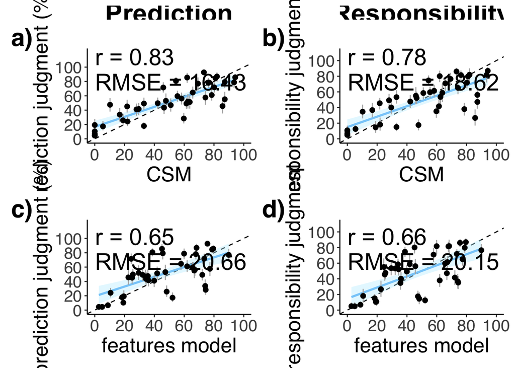

```r
df.plot = df.exp3.master %>%
  select(trial, index, r_mean, r_low, r_high, p_mean, p_low, p_high,
         hsm = any_of(xval_bestmodel)) %>%
  left_join(df.exp123.regression %>%
              filter(exp == 3) %>%
              select(trial, index, features = fit123),
            by = c("trial", "index")) %>%
  mutate(across(c(features, hsm, contains("r_"), contains("p_")), ~.*100))

# PREDICTION

# hsm model
plot.hsm_prediction = ggplot(df.plot, aes(x = hsm, y = p_mean)) +
  geom_abline(intercept = 0, slope = 1, linetype = 2) +
  stat_smooth(method = "lm", color = "lightskyblue", fill='lightblue1') +
  geom_errorbar(aes(ymin = p_low, ymax = p_high), width = 0, color='grey70') +
  geom_point(size = 2, color='black') +
  annotate(geom = "text",
           label = str_c("r = ", cor(df.plot$hsm, df.plot$p_mean) %>% round(2)),
           x = .2, y = Inf, hjust = 0, vjust = 1, size = 8) +
  annotate(geom = "text",
           label = str_c("RMSE = ", rmse(df.plot$hsm, df.plot$p_mean) %>% round(2)),
           x = .2, y = Inf, hjust = 0, vjust = 2.5, size = 8) +
  labs(x = "CSM", y = "prediction judgment (%)", tag = "a)") +
  scale_x_continuous(breaks = seq(0, 100, 20), limits = c(0, 100)) +
  scale_y_continuous(breaks = seq(0, 100, 20), limits = c(0, 120)) +
  theme(panel.grid = element_blank(), plot.tag = element_text(face = "bold"))

# features model
plot.features_prediction = ggplot(df.plot, aes(x = features, y = p_mean)) +
  geom_abline(intercept = 0, slope = 1, linetype = 2) +
  stat_smooth(method = "lm", color = "lightskyblue", fill='lightblue1') +
  geom_errorbar(aes(ymin = p_low, ymax = p_high), width = 0, color='grey70') +
  geom_point(size = 2, color='black') +
  annotate(geom = "text",
           label = str_c("r = ", cor(df.plot$features, df.plot$p_mean) %>% round(2)),
           x = .2, y = Inf, hjust = 0, vjust = 1.5, size = 8) +
  annotate(geom = "text",
           label = str_c("RMSE = ", rmse(df.plot$features, df.plot$p_mean) %>% round(2)),
           x = .2, y = Inf, hjust = 0, vjust = 3, size = 8) +
  labs(x = "features model", y = "prediction judgment (%)", tag = "c)") +
  scale_x_continuous(breaks = seq(0, 100, 20), limits = c(0, 100)) +
  scale_y_continuous(breaks = seq(0, 100, 20), limits = c(0, 120)) +
  theme(panel.grid = element_blank(), plot.tag = element_text(face = "bold"))

# RESPONSIBILITY

# hsm model
plot.hsm_responsibility = ggplot(df.plot, aes(x = hsm, y = r_mean)) +
  geom_abline(intercept = 0, slope = 1, linetype = 2) +
  stat_smooth(method = "lm", color = "lightskyblue", fill='lightblue1') +
  geom_errorbar(aes(ymin = r_low, ymax = r_high), width = 0, color='grey70') +
  geom_point(size = 2, color='black') +
  annotate(geom = "text",
           label = str_c("r = ", cor(df.plot$hsm, df.plot$r_mean) %>% round(2)),
           x = .2, y = Inf, hjust = 0, vjust = 1, size = 8) +
  annotate(geom = "text",
           label = str_c("RMSE = ", rmse(df.plot$hsm, df.plot$r_mean) %>% round(2)),
           x = .2, y = Inf, hjust = 0, vjust = 2.5, size = 8) +
  labs(x = "CSM", y = "responsibility judgment", tag = "b)") +
  scale_x_continuous(breaks = seq(0, 100, 20), limits = c(0, 100)) +
  scale_y_continuous(breaks = seq(0, 100, 20), limits = c(0, 110)) +
  theme(panel.grid = element_blank(), plot.tag = element_text(face = "bold"))

# features model
plot.features_responsibility = ggplot(df.plot, aes(x = features, y = r_mean)) +
  geom_abline(intercept = 0, slope = 1, linetype = 2) +
  stat_smooth(method = "lm", color = "lightskyblue", fill='lightblue1') +
  geom_errorbar(aes(ymin = r_low, ymax = r_high), width = 0, color='grey70') +
  geom_point(size = 2, color='black') +
  annotate(geom = "text",
           label = str_c("r = ", cor(df.plot$features, df.plot$r_mean) %>% round(2)),
           x = .2, y = Inf, hjust = 0, vjust = 1.5, size = 8) +
  annotate(geom = "text",
           label = str_c("RMSE = ", rmse(df.plot$features, df.plot$r_mean) %>% round(2)),
           x = .2, y = Inf, hjust = 0, vjust = 3, size = 8) +
  labs(x = "features model", y = "responsibility judgment", tag = "d)") +
  scale_x_continuous(breaks = seq(0, 100, 20), limits = c(0, 100)) +
  scale_y_continuous(breaks = seq(0, 100, 20), limits = c(0, 110)) +
  theme(panel.grid = element_blank(), plot.tag = element_text(face = "bold"))

col1 <- ggplot() +
  annotate(geom = 'text', x=-5, y=0, label="Prediction", size=9, fontface = "bold" ) +
  theme_void()
col2 <- ggplot() +
  annotate(geom = 'text', x=0, y=0, label="Responsibility", size=9, fontface = "bold") +
  theme_void()

(col1 / plot.hsm_prediction / plot.features_prediction) +
  plot_layout(heights = c(0.15, 1, 1)) |
  (col2 / plot.hsm_responsibility / plot.features_responsibility) +
  plot_layout(heights = c(0.15, 1, 1))
ggsave("../../figures/plots/exp3/exp3_plots.pdf", width = 10, height = 10)
```

### 8.3.3 prediction vs responsibility

```r
df.plot = df.exp3.prediction %>%
  mutate(experiment = "prediction") %>%
  bind_rows(df.exp3.responsibility %>%
              mutate(experiment = "responsibility")) %>%
  group_by(trial, experiment) %>%
  summarize(mean = mean(response),
            low = smean.cl.boot(response)[2],
            high = smean.cl.boot(response)[3]) %>%
  pivot_wider(names_from = experiment,
              values_from = c(mean, low, high))

g2 = ggplot(df.exp3.trials, aes(y = r_mean, x = p_mean)) +
  geom_abline(intercept = 0, slope = 1, linetype = 2) +
  geom_smooth(method = "lm", color = "lightskyblue", fill="lightblue1") +
  geom_errorbarh(aes(xmin = p_low, xmax = p_high), color = "gray60") +
  geom_errorbar(aes(ymin = r_low, ymax = r_high), color = "gray60") +
  geom_point(size = 2) +
  # geom_text_repel(aes(label = trial), size = 6) +
  annotate(geom = "text",
           label = str_c("r = ",
                         cor(df.plot$mean_prediction, df.plot$mean_responsibility) %>%
                           round(2)),
           x = 0, y = Inf, hjust = 0, vjust = 1.5, size = 8) +
  annotate(geom = "text",
           label = str_c("RMSE = ",
                         rmse(df.plot$mean_prediction, df.plot$mean_responsibility) %>%
                           round(2)),
           x = 0, y = Inf, hjust = 0, vjust = 3, size = 8) +
  labs(x = "prediction judgment (%)", y = "responsibility judgment") +
  scale_x_continuous(breaks = seq(0, 100, 20)) +
  scale_y_continuous(breaks = seq(0, 100, 20)) +
  coord_cartesian(xlim = c(0, 100), ylim = c(0, 100)) +
  theme(text = element_text(size = 20),
    panel.grid = element_blank())

ggsave(paste0("../../figures/plots/exp3/exp3_prediction_responsibility.pdf"),
       width = 5, height = 5)
```

## 8.4 Joint

### 8.4.1 Selection vs prediction

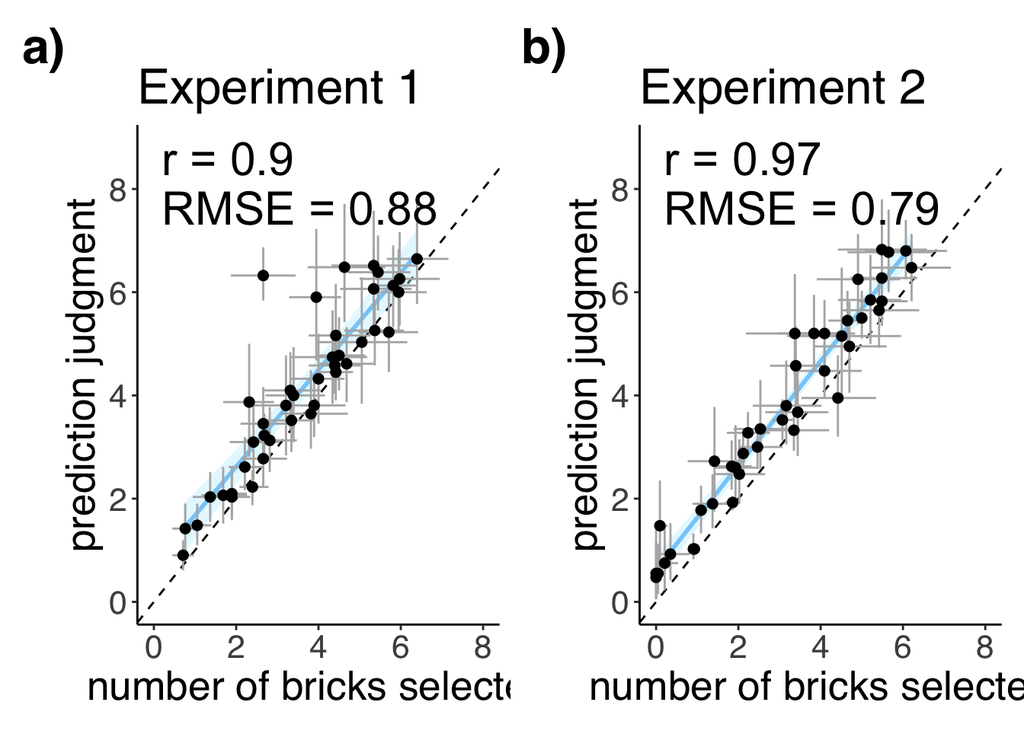

```r
# exp1: selection vs prediction
df.plot = df.exp1.selection.long %>%
  group_by(participant, trial, response) %>%
  summarize(count = n()) %>%
  ungroup() %>%
  complete(participant, trial, response) %>%
  filter(response == 1) %>%
  mutate(count = ifelse(is.na(count), 0, count)) %>%
  group_by(trial) %>%
  summarize(s_mean = mean(count),
            s_low = smean.cl.boot(count)[2],
            s_high = smean.cl.boot(count)[3]) %>%
  left_join(df.exp1.trials %>%
    select(trial, p_mean, p_low, p_high, n_bricks),
    by = "trial")
p1 = ggplot(df.plot, aes(x = s_mean, y = p_mean)) +
  geom_abline(intercept = 0, slope = 1, linetype = 2) +
  geom_smooth(method = "lm", color = "lightskyblue", fill='lightblue1') +
  geom_errorbarh(aes(xmin = s_low, xmax = s_high), height = 0, color='grey70') +
  geom_errorbar(aes(ymin = p_low, ymax = p_high), width = 0, color='grey70') +
  geom_point(size = 2, color='black') +
  annotate(geom = "text",
           label = str_c("r = ", cor(df.plot$s_mean, df.plot$p_mean) %>% round(2)),
           x = .2, y = Inf, hjust = 0, vjust = 1.5, size = 8) +
  annotate(geom = "text",
           label = str_c("RMSE = ", rmse(df.plot$s_mean, df.plot$p_mean) %>% round(2)),
           x = .2, y = Inf, hjust = 0, vjust = 3, size = 8) +
  annotate(geom = "text",
           label = "", x = 0, y = 0, hjust = 0) +
  labs(title = "Experiment 1",
       x = "number of bricks selected",
       y = "prediction judgment") +
  # coord_cartesian(ylim = c(0, NA), xlim = c(0, NA)) +
  scale_x_continuous(breaks = seq(0, 8, 2), labels = seq(0, 8, 2), limits = c(0, 8)) +
  scale_y_continuous(breaks = seq(0, 8, 2), labels = seq(0, 8, 2), limits = c(0, 8.8)) +
  theme(text = element_text(size = 20),
    panel.grid = element_blank())

# exp2: selection vs prediction
df.plot = df.exp2.selection.long %>%
  group_by(participant, trial, response) %>%
  summarize(count = n()) %>%
  ungroup() %>%
  complete(participant, trial, response) %>%
  filter(response == 1) %>%
  mutate(count = ifelse(is.na(count), 0, count)) %>%
  group_by(trial) %>%
  summarize(s_mean = mean(count),
            s_low = smean.cl.boot(count)[2],
            s_high = smean.cl.boot(count)[3]) %>%
  left_join(df.exp2.trials %>%
    select(trial, p_mean, p_low, p_high, n_bricks),
    by = "trial")
p2 = ggplot(df.plot, aes(x = s_mean, y = p_mean)) +
  geom_abline(intercept = 0, slope = 1, linetype = 2) +
  geom_smooth(method = "lm", color = "lightskyblue", fill='lightblue1') +
  geom_errorbarh(aes(xmin = s_low, xmax = s_high), height = 0, color='grey70') +
  geom_errorbar(aes(ymin = p_low, ymax = p_high), width = 0, color='grey70') +
  geom_point(size = 2, color='black') +
  annotate(geom = "text",
           label = str_c("r = ", cor(df.plot$s_mean, df.plot$p_mean) %>% round(2)),
           x = .2, y = Inf, hjust = 0, vjust = 1.5, size = 8) +
  annotate(geom = "text",
           label = str_c("RMSE = ", rmse(df.plot$s_mean, df.plot$p_mean) %>% round(2)),
           x = .2, y = Inf, hjust = 0, vjust = 3, size = 8) +
  annotate(geom = "text",
           label = "", x = 0, y = 0, hjust = 0) +
  labs(title = "Experiment 2",
       x = "number of bricks selected",
       y = "prediction judgment") +
  scale_x_continuous(breaks = seq(0, 8, 2), labels = seq(0, 8, 2), limits = c(0, 8)) +
  scale_y_continuous(breaks = seq(0, 8, 2), labels = seq(0, 8, 2), limits = c(0, 8.8)) +
  theme(text = element_text(size = 20),
        panel.grid = element_blank())

p1 + p2 + plot_annotation(tag_levels = "a", tag_suffix = ")") &
  theme(plot.tag = element_text(face = 'bold'))
# ggsave("../../figures/plots/selection_prediction.pdf",width = 12,height = 6)
```

### 8.4.2 Prediction vs responsibility

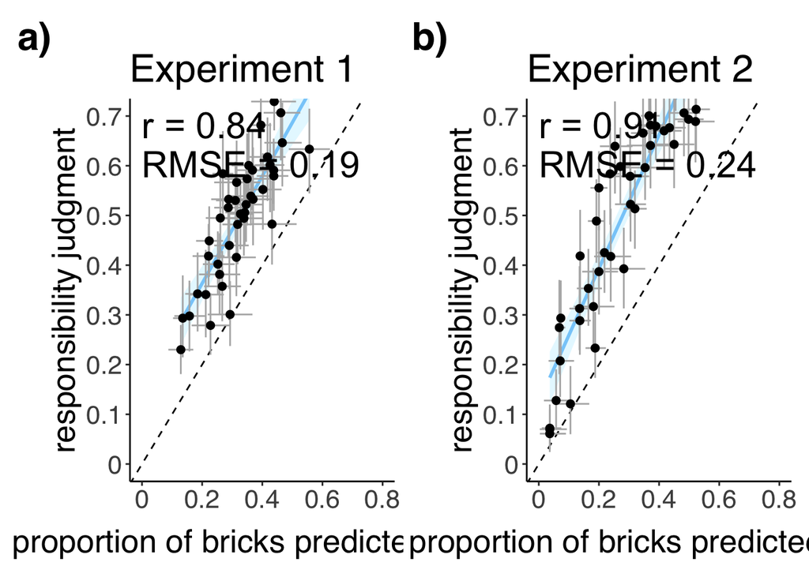

```r
# exp1: prediction vs responsibility
df.plot = df.exp1.trials %>%
  select(trial, r_mean, r_low, r_high, p_mean, p_low, p_high, n_bricks) %>%
  mutate(across(contains("r_"), ~./100)) %>%
  mutate(across(contains("p_"), ~./n_bricks))
p1 = ggplot(df.plot, aes(x = p_mean, y = r_mean)) +
  geom_abline(intercept = 0, slope = 1, linetype = 2) +
  geom_smooth(method = "lm", color = "lightskyblue", fill="lightblue1") +
  geom_errorbar(aes(ymin = r_low, ymax = r_high), width = 0, color="grey70") +
  geom_errorbarh(aes(xmin = p_low, xmax = p_high), height = 0, color="grey70") +
  geom_point(size = 2, color="black") +
  annotate(geom = "text",
           label = str_c("r = ", cor(df.plot$r_mean, df.plot$p_mean) %>% round(2)),
           x = 0, y = Inf, hjust = 0, vjust = 1.5, size = 8) +
  annotate(geom = "text",
           label = str_c("RMSE = ", rmse(df.plot$r_mean, df.plot$p_mean) %>% round(2)),
           x = 0, y = Inf, hjust = 0, vjust = 3, size = 8) +
  labs(title = "Experiment 1",
       x = "proportion of bricks predicted to fall", y = "responsibility judgment") +
  scale_x_continuous(breaks = seq(0, 1, .2), labels = seq(0, 1, .2)) +
  scale_y_continuous(breaks = seq(0, 1, .1), labels = seq(0, 1, .1)) +
  coord_cartesian(xlim = c(0, 0.8), ylim = c(0, 0.7)) +
  theme(text = element_text(size = 20),
        panel.grid = element_blank(),
        axis.title.x = element_text(margin = margin(t = 10)))

# exp2: prediction vs responsibility
df.plot = df.exp2.trials %>%
  select(trial, r_mean, r_low, r_high, p_mean, p_low, p_high, n_bricks) %>%
  mutate(across(contains("r_"), ~./100)) %>%
  mutate(across(contains("p_"), ~./n_bricks))
p2 = ggplot(df.plot, aes(x = p_mean, y = r_mean)) +
  geom_abline(intercept = 0, slope = 1, linetype = 2) +
  geom_smooth(method = "lm", color = "lightskyblue", fill="lightblue1") +
  geom_errorbar(aes(ymin = r_low, ymax = r_high), width = 0, color="grey70") +
  geom_errorbarh(aes(xmin = p_low, xmax = p_high), height = 0, color="grey70") +
  geom_point(size = 2, color="black") +
  annotate(geom = "text",
           label = str_c("r = ", cor(df.plot$r_mean, df.plot$p_mean) %>% round(2)),
           x = 0, y = Inf, hjust = 0, vjust = 1.5, size = 8) +
  annotate(geom = "text",
           label = str_c("RMSE = ", rmse(df.plot$r_mean, df.plot$p_mean) %>% round(2)),
           x = 0, y = Inf, hjust = 0, vjust = 3, size = 8) +
  labs(title = "Experiment 2",
       x = "proportion of bricks predicted to fall", y = "responsibility judgment") +
  scale_x_continuous(breaks = seq(0, 1, .2), labels = seq(0, 1, .2)) +
  scale_y_continuous(breaks = seq(0, 1, .1), labels = seq(0, 1, .1)) +
  coord_cartesian(xlim = c(0, 0.8), ylim = c(0, 0.7)) +
  theme(text = element_text(size = 20),
        panel.grid = element_blank(),
        axis.title.x = element_text(margin = margin(t = 10)))

p1 + p2 + plot_annotation(tag_levels = "a", tag_suffix = ")") &
  theme(plot.tag = element_text(face = 'bold'))
# ggsave("../../figures/plots/prediction_responsibility.pdf",width = 8,height = 5)
```